# R Notebook

# Load required packages

Also set up theme for ggplot, and set default stringsAsFactors to F

```r
library(GenomicRanges)
library(BSgenome.Mmusculus.UCSC.mm10)
library(rtracklayer)
library(RColorBrewer)
library(DESeq2)
```

```r
library(gplots)
library(pheatmap)
library(pzfx)
library(egg)
library(rstatix)
library(tidyverse)
library(ggrepel)

options(stringsAsFactors = F)

theme_set(theme_classic())
theme_update(plot.background = element_blank(),
             panel.background = element_blank(),
             legend.background = element_blank(),
             legend.key = element_blank())
```

# Figure S1A - activation

Flow histograms generated in flowjo. Percentages of CD69+ cells are in “activation_status/surface markers.pzfx”, table 1

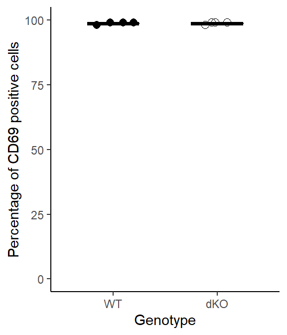

```r
read_pzfx("activation_status/surface markers.pzfx", 1) %>%
  as_tibble() %>%
  rename(Marker = ROWTITLE) %>%
  gather(Sample, Percent_positive, -Marker) %>%
  mutate(Genotype = sub(" *_[0-9]", "", Sample)) %>%
  mutate(Genotype = factor(Genotype, levels = c("WT", "dKO"))) ->
    Activation_markers_percent_positive

Activation_markers_percent_positive %>%
  filter(Marker == "CD69") %>%
    ggplot(aes(x = Genotype, y = Percent_positive, shape = Genotype)) +
      stat_summary(geom = "crossbar", fun = "mean", fun.min = "mean", fun.max = "mean", width = 0.5, colour = "black") +
      geom_jitter(height=0, width=0.2, size = 2.5) +
      coord_cartesian(ylim = c(0,100)) +
      scale_shape_manual(values = c(16,1)) +
      ylab("Percentage of CD69 positive cells") +
      theme(legend.position = "none")
```

```r
ggsave("Figure_panels/FigS1A_Percent_CD69.pdf", useDingbats = F)
```

# Figure S1B - ZFP family qPCR

Read in and merge graphpad tables for each ZFP36-family gene. Extract time and genotype from sample names, and filter for 24h.

```r
read_pzfx("timecourse_RNA_protein/121108 RNA TTP CD4-AB wt&cKO 0,24,48,72,96h.pzfx", 1) %>%
  add_column(Gene = "Zfp36") ->
    Zfp36_family_RNA

read_pzfx("timecourse_RNA_protein/121108 RNA Tis11B CD4-AB wt&cKO 0,24,48,72,96h.pzfx", 1) %>%
  add_column(Gene = "Zfp36l1") %>%
    bind_rows(Zfp36_family_RNA) ->
    Zfp36_family_RNA

read_pzfx("timecourse_RNA_protein/121108 RNA Tis11D CD4-AB wt&cKO 0,24,48,72,96h.pzfx", 1) %>%
  add_column(Gene = "Zfp36l2") %>%
    bind_rows(Zfp36_family_RNA) ->
    Zfp36_family_RNA

Zfp36_family_RNA %>%
  pivot_longer(-Gene, names_to = "Sample", values_to = "Abundance") %>%
    mutate(Time = sub(".* ([0-9]+h)_[0-9]", "\\1", Sample)) %>%
    mutate(Genotype = factor(grepl("wt", Sample), levels = c(T,F), labels = c("Ctrl", "dKO"))) %>%
  filter(Time == "24h") ->
      Zfp36_family_RNA
```

Normalise to mean in controls, so that scale for all genes is comparable

Ie, we want to know the expression in KOs relative to expression in control (which will be set to 1)

```r
Zfp36_family_RNA %>%
  group_by(Gene, Genotype) %>%
  summarise(mean_abundance = mean(Abundance), .groups = "drop") %>%
  unite(Condition, Gene, Genotype) ->
    Zfp36_family_RNA_mean

Zfp36_family_RNA %>%
  mutate(Abundance_normMean = case_when(
    Gene == "Zfp36" ~ Abundance/Zfp36_family_RNA_mean$mean_abundance[Zfp36_family_RNA_mean$Condition == "Zfp36_Ctrl"],
    Gene == "Zfp36l1" ~ Abundance/Zfp36_family_RNA_mean$mean_abundance[Zfp36_family_RNA_mean$Condition == "Zfp36l1_Ctrl"],
    Gene == "Zfp36l2" ~ Abundance/Zfp36_family_RNA_mean$mean_abundance[Zfp36_family_RNA_mean$Condition == "Zfp36l2_Ctrl"]
  )) ->
  Zfp36_family_RNA
```

Plot data

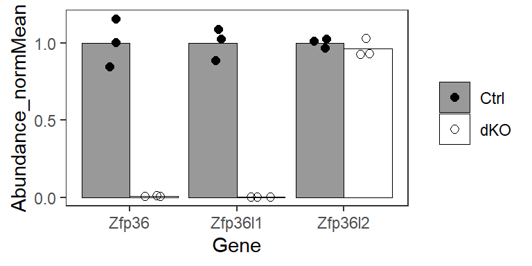

```r
Zfp36_family_RNA %>%
  ggplot(aes(x = Gene, y = Abundance_normMean, fill = Genotype, shape = Genotype)) +
    stat_summary(geom = "bar", fun = "mean", position = "dodge", colour = "black", size = 0.3) +
    geom_point(position = position_jitterdodge(dodge.width = 0.9), size = 2) +
    theme_bw() +
    theme(panel.grid = element_blank(), legend.position = "right", legend.background = element_blank(), legend.title = element_blank(), plot.background = element_blank(), panel.background = element_blank()) +
    scale_fill_manual(values = c("grey60", "white")) +
    scale_shape_manual(values = c(19, 1)) +
    scale_y_continuous(breaks = c(0, 0.5, 1))
```

```r
ggsave("Figure_panels/FigS1B_ZFPqPCR.pdf", useDingbats = F)
```

# Figure 1A-D, S1C-E; MA plots

## Read in counts for all

I have raw counts for nascent mRNA, total mRNA and ribosome-protected mRNA. All quantified using Seqmonk, assuming single end, stranded data (opposing for nascent and total; same strand for Ribo-seq). For nascent and total used mRNA annotations, for Ribo-seq used CDS - all with merged isoforms.

One issue with the way Seqmonk merges isoforms (at least with v1.44.0) is that if they do not overlap, you can end up with two rows for a gene corresponding to different (groups of) isoforms. I have a file for the v90 annotation which indicates how to deal with each duplicate gene name - either add together, or discard one or other row (identified by coordinates). This was curated manually.

I also have a file containing some changes in gene name, since when the curation above was done, some isoforms had been updated to now be assigned to separate gene names.

First define function which takes the reads that have been read in and corrects the duplicate rows, and gene names, as defined by the file above.

It will also convert the counts into a dataframe suitable for input into DESeq2 - ie retain just the gene names as row names, and counts in each column.

Since some samples are unbalanced mixtures of sexes, we will also remove Y chromosome genes to avoid artefacts. Also remove Xist/Tsix and overlapping gene (Gm26992).

```r
RNA_seqmonk_to_corrected_counts <- function(expression_data){
  GRCm38_v90_nomenclature <- read_tsv("Annotations/GRCm38_v90_nomenclature.txt", col_types = cols(Chromosome = col_character(), mRNA_duplicates = col_character()))
  mRNA_duplication <- read_tsv("Annotations/duplicated_probe_in_mRNA.txt")
  start_col <- which(colnames(expression_data) == "Distance") + 1 # the first column containing counts is the column following 'Distance' - not always same index!
  GRCm38_name_changes <- GRCm38_v90_nomenclature[GRCm38_v90_nomenclature$name_change==T,]
  expression_data$Gene_name <- expression_data$Probe
  expression_data$gene_and_location <- paste(expression_data$Probe, expression_data$Chromosome,expression_data$Start, expression_data$End,expression_data$Probe_Strand)
  expression_data$Gene_name[expression_data$gene_and_location %in% GRCm38_name_changes$gene_and_location] <- GRCm38_name_changes$Gene_name[match(expression_data$gene_and_location[expression_data$gene_and_location %in% GRCm38_name_changes$gene_and_location], GRCm38_name_changes$gene_and_location)]
  GRCm38_name_changes <- GRCm38_name_changes[!GRCm38_name_changes$gene_and_location %in% expression_data$gene_and_location,]
  expression_data$Gene_name[expression_data$Probe %in% GRCm38_name_changes$Probe] <- GRCm38_name_changes$Gene_name[match(expression_data$Probe[expression_data$Probe %in% GRCm38_name_changes$Probe], GRCm38_name_changes$Probe)]
  expression_data <- expression_data[!expression_data$gene_and_location %in% mRNA_duplication$gene_and_location[mRNA_duplication$action=="exclude"],]
  for(gene in na.omit(unique(mRNA_duplication$Probe[mRNA_duplication$action=="add"]))){
    subset <- expression_data[expression_data$Probe == gene,]
    expression_data$Start[expression_data$Probe == gene] <- min(subset$Start)
    expression_data$End[expression_data$Probe == gene] <- max(subset$End)
    for(i in start_col:(ncol(expression_data)-2)){
      expression_data[expression_data$Probe == gene, i] <- sum(subset[,i])
    }
  }
  expression_data <- expression_data[!duplicated(expression_data$Gene_name),]
  expression_data <- expression_data[!(expression_data$Chromosome == "Y" | expression_data$Gene_name %in% c("Xist","Tsix","Gm26992")),]
  expression_data %>%
    distinct(Gene_name, .keep_all = T) %>%
    filter(!(Chromosome == "Y" | Gene_name %in% c("Xist","Tsix","Gm26992"))) %>%
    select(Gene_name, start_col:(ncol(expression_data)-2)) %>% # up to the last column of the original dataframe - 2 additonal columns added above
    column_to_rownames("Gene_name")
  }
```

Read in raw counts for each dataset, and correct using the function above

```r
read_tsv("Raw_counts_Seqmonk/RNA_dKO_raw_counts.txt", col_types = cols(Chromosome = col_character())) %>%
  rename_with(~ gsub(" ", "_", .x)) %>%
  RNA_seqmonk_to_corrected_counts() -> RNA_raw_counts_corrected
```

```
##
## Note: Using an external vector in selections is ambiguous.
## i Use `all_of(start_col)` instead of `start_col` to silence this message.
## i See <https://tidyselect.r-lib.org/reference/faq-external-vector.html>.
```

```r
read_tsv("Raw_counts_Seqmonk/Nascent_raw_counts.txt", col_types = cols(Chromosome = col_character())) %>%
  rename_with(~ gsub(" ", "_", .x)) %>%
  RNA_seqmonk_to_corrected_counts() -> raw_counts_nascent_corrected
read_tsv("Raw_counts_Seqmonk/Ribo_cds_raw_counts.txt", col_types = cols(Chromosome = col_character())) %>%
  rename_with(~ gsub(" ", "_", .x)) %>%
  RNA_seqmonk_to_corrected_counts() -> Riboseq_raw_counts_corrected
```

```
## Warning in min(subset$Start): no non-missing arguments to min; returning Inf
```

```
## Warning in max(subset$End): no non-missing arguments to max; returning -Inf
```

```
## Warning in min(subset$Start): no non-missing arguments to min; returning Inf
```

```
## Warning in max(subset$End): no non-missing arguments to max; returning -Inf
```

Warnings for RiboSeq are because some genes with duplicate names don’t have a CDS so the subsets are empty - but equally there are no values to replace so this does not matter.

Single KO data: (also read in and rename columns to correspond to GEO; export with just gene names and counts)

```r
read_tsv("Raw_counts_Seqmonk/RNA_sKO_raw_counts.txt", col_types = cols(Chromosome = col_character())) %>%
  rename_with(~ gsub(" ", "_", .x)) %>%
  RNA_seqmonk_to_corrected_counts() -> RNA_sKO_raw_counts_corrected
read_tsv("Raw_counts_Seqmonk/RNA_sKO_raw_counts.txt", col_types = cols(Chromosome = col_character())) %>%
  select(Probe, ends_with("bam")) %>%
  rename_with(~ sub("_24h.*", "", .x)) %>%
  rename_with(~ paste0("mRNA_", .x)) %>%
  rename_with(~ sub("TTP", "A", .x)) %>%
  rename_with(~ sub("WT", "Ctrl_", .x)) %>%
  rename_with(~ sub("A_KO", "A_Zfp36_sKO_", .x)) %>%
  rename_with(~ sub("B_KO", "B_Zfp36l1_sKO_", .x)) %>%
  rename(Gene = mRNA_Probe) %>%
  rename(mRNA_A_Ctrl_2 = mRNA_A_Ctrl_3) %>%
  rename(mRNA_B_Zfp36l1_sKO_2 = mRNA_B_Zfp36l1_sKO_3) %>%
  select(Gene, contains("A_Ctr"), contains("A_Z"), contains("B_Ctr"), contains("B_Z")) %>%
  write_tsv("mRNA_sKO_raw_counts.txt")
```

Simplify column names - in the case of nascent and total RNA I have tables to read in which define which sample is which since the names are not descriptive.

```r
read_tsv("Raw_counts_Seqmonk/RNA_dKO_samples.txt") -> RNA_dKO_samples
colnames(RNA_raw_counts_corrected)[match(RNA_dKO_samples$Bam_name,colnames(RNA_raw_counts_corrected))] <- RNA_dKO_samples$Sample_name

read_tsv("Raw_counts_Seqmonk/Nascent_samples.txt") %>%
  mutate(geno = if_else(geno == "wt", "Ctrl", "KO")) %>%
  unite(sample_name, geno, desc, expt) %>%
  mutate(sample_name = sub("-e", "E", sample_name)) -> Nascent_samples
colnames(raw_counts_nascent_corrected)[match(Nascent_samples$sample.id,gsub("-", ".", colnames(raw_counts_nascent_corrected)))] <- Nascent_samples$sample_name

colnames(Riboseq_raw_counts_corrected) <- sub("lane._(RF_...)_[ACGT].*","\\1", colnames(Riboseq_raw_counts_corrected))

RNA_sKO_raw_counts_corrected %>%
  rename_with(~ sub("_24h.*", "", .x)) -> RNA_sKO_raw_counts_corrected
```

Limit analysis to only include genes with a CDS, ie those that are in the Ribo-seq as well as other datasets.

```r
summary(rownames(RNA_raw_counts_corrected) %in% rownames(raw_counts_nascent_corrected))
```

```
##    Mode    TRUE
## logical   33456
```

```r
#   Mode    TRUE
#logical   33456
summary(rownames(Riboseq_raw_counts_corrected) %in% rownames(raw_counts_nascent_corrected))
```

```
##    Mode   FALSE    TRUE
## logical     253   21985
```

```r
#   Mode   FALSE    TRUE
#logical     253   21985
### These are all Ig segments

summary(rownames(raw_counts_nascent_corrected) %in% rownames(Riboseq_raw_counts_corrected))
```

```
##    Mode   FALSE    TRUE
## logical   11471   21985
```

```r
#   Mode   FALSE    TRUE
#logical   11471   21985


summary(rownames(RNA_sKO_raw_counts_corrected) %in% rownames(RNA_raw_counts_corrected))
```

```
##    Mode    TRUE
## logical   33456
```

```r
#   Mode    TRUE
#logical   33456
```

Nascent and total RNA (sKO and dKO) have exactly the same genes represented (as would be expected since both based on mRNA annotations).

Limit nascent and total RNA to only genes present in Riboseq Limit Riboseq to only genes present in total RNAseq.

```r
RNA_raw_counts_complete <- RNA_raw_counts_corrected[rownames(RNA_raw_counts_corrected) %in% rownames(Riboseq_raw_counts_corrected),]
Nascent_raw_counts_complete <- raw_counts_nascent_corrected[rownames(raw_counts_nascent_corrected) %in% rownames(Riboseq_raw_counts_corrected),]
Ribo_raw_counts_complete <- Riboseq_raw_counts_corrected[rownames(Riboseq_raw_counts_corrected) %in% rownames(RNA_raw_counts_corrected),]

RNA_sKO_raw_counts_complete <- RNA_sKO_raw_counts_corrected[rownames(RNA_sKO_raw_counts_corrected) %in% rownames(Riboseq_raw_counts_corrected),]
```

## DESeq2 analysis of total RNA-seq (dKO)

Create coldata and run DESeq2 for total RNA-seq

Extract normalised counts, and output from LFCshrink for KO vs Ctrl comparison, with normal LFC shrinkage.

```r
tibble(sample = colnames(RNA_raw_counts_complete)) %>%
  mutate(Genotype = if_else(grepl("Ctrl", sample), "Ctrl", "KO")) %>%
  column_to_rownames("sample") -> coldata_RNA

RNA_raw_counts_complete %>%
  DESeqDataSetFromMatrix(coldata_RNA, design = ~Genotype) %>%
  DESeq() -> dds_RNA
counts(dds_RNA, normalized = T) %>%
  as_tibble(rownames = "Gene") -> norm_counts_RNA
dds_RNA %>%
  lfcShrink(coef = 2, type = "normal") %>%
  as_tibble(rownames = "Gene") -> res_RNA
```

```
## using 'normal' for LFC shrinkage, the Normal prior from Love et al (2014).
##
## Note that type='apeglm' and type='ashr' have shown to have less bias than type='normal'.
## See ?lfcShrink for more details on shrinkage type, and the DESeq2 vignette.
## Reference: https://doi.org/10.1093/bioinformatics/bty895
```

For norm_counts_RNA, add a column with the log2 mean in control cells - used to give indication of relative expression levels in some later figures.

```r
norm_counts_RNA %>%
  mutate(Ctrl_mean = rowMeans(log2(select(., contains("Ctrl"))+1))) -> norm_counts_RNA
```

### Table S2 - mRNA DE genes

Export significantly altered genes for supplementary table (increased and decreased separately):

```r
res_RNA %>%
  filter(baseMean > 10) %>%
  filter(padj < 0.05) %>%
  filter(log2FoldChange > 0) %>%
  arrange(padj) %>%
  write_tsv("Supplementary_tables/TableS2_RNAincreased.txt")

res_RNA %>%
  filter(baseMean > 10) %>%
  filter(padj < 0.05) %>%
  filter(log2FoldChange < 0) %>%
  arrange(padj) %>%
  write_tsv("Supplementary_tables/TableS2_RNAdecreased.txt")
```

## DESeq2 analysis of sKO RNA-seq

Create coldata and run DESeq2 for total RNA-seq in sKO

Extract normalised counts, and output from LFCshrink for KO vs Ctrl comparison in TTP and Tis11b sKO, with normal LFC shrinkage.

```r
RNA_sKO_raw_counts_complete %>%
  select(starts_with("TTP")) -> TTP_sKO_raw_counts

RNA_sKO_raw_counts_complete %>%
  select(starts_with("B")) -> Tis11b_sKO_raw_counts

tibble(sample = colnames(TTP_sKO_raw_counts)) %>%
  mutate(Genotype = if_else(grepl("WT", sample), "Ctrl", "KO")) %>%
  column_to_rownames("sample") -> coldata_TTP_sKO
tibble(sample = colnames(Tis11b_sKO_raw_counts)) %>%
  mutate(Genotype = if_else(grepl("WT", sample), "Ctrl", "KO")) %>%
  column_to_rownames("sample") -> coldata_Tis11b_sKO

TTP_sKO_raw_counts %>%
  DESeqDataSetFromMatrix(coldata_TTP_sKO, design = ~Genotype) %>%
  DESeq() -> dds_TTP_sKO
Tis11b_sKO_raw_counts %>%
  DESeqDataSetFromMatrix(coldata_Tis11b_sKO, design = ~Genotype) %>%
  DESeq() -> dds_Tis11b_sKO
counts(dds_TTP_sKO, normalized = T) %>%
  as_tibble(rownames = "Gene") -> norm_counts_TTP_sKO
dds_TTP_sKO %>%
  lfcShrink(coef = 2, type = "normal") %>%
  as_tibble(rownames = "Gene") -> res_TTP_sKO
```

```
## using 'normal' for LFC shrinkage, the Normal prior from Love et al (2014).
##
## Note that type='apeglm' and type='ashr' have shown to have less bias than type='normal'.
## See ?lfcShrink for more details on shrinkage type, and the DESeq2 vignette.
## Reference: https://doi.org/10.1093/bioinformatics/bty895
```

```r
counts(dds_Tis11b_sKO, normalized = T) %>%
  as_tibble(rownames = "Gene") -> norm_counts_Tis11b_sKO
dds_Tis11b_sKO %>%
  lfcShrink(coef = 2, type = "normal") %>%
  as_tibble(rownames = "Gene") -> res_Tis11b_sKO
```

```
## using 'normal' for LFC shrinkage, the Normal prior from Love et al (2014).
##
## Note that type='apeglm' and type='ashr' have shown to have less bias than type='normal'.
## See ?lfcShrink for more details on shrinkage type, and the DESeq2 vignette.
## Reference: https://doi.org/10.1093/bioinformatics/bty895
```

## Comparison between sKO and dKO

These datasets were generated independently, with separate controls for the two sKO and dKO experiments - they can’t be integrated and eg normalised together as they are not sufficiently comparable. When DESeq2 is run independently, the log2 fold change shrinkage will be based on separate modelling, so the L2FC cannot really be compared between them.

To try and get around that, I will use an adapted version of the intensityDifference function (see intensityDifference.R). Originally by Simon Andrews (https://github.com/s-andrews/intensitydiff), version used here is modified to allow ‘averages’ and ‘differences’ to be provided directly, rather than calculated from separate data for Ctrl and KO, and also for lists of sets of averages/differences to be provided, and then modelled together (so that the potentially bigger L2FC in the dKO is not normalised away in the z-score calculation).

It calculates z-scores for the differences based on the local standard deviation of the expression levels, since the amount of noise decreases as expression increases. Ie, low expressed genes are penalised more.

In this case, we want to start from the raw L2FC values (not already shrunken by lfcShrink) as the differences, and the baseMean as the averages.

```r
source("intensityDifference.R")

results(dds_RNA) %>%
  as_tibble(rownames = "Gene") %>%
  filter(baseMean > 10) %>%
  filter(!is.na(log2FoldChange)) -> l2fc_raw_dKO
results(dds_TTP_sKO) %>%
  as_tibble(rownames = "Gene") %>%
  filter(baseMean > 10) %>%
  filter(!is.na(log2FoldChange)) -> l2fc_raw_TTP_sKO
results(dds_Tis11b_sKO) %>%
  as_tibble(rownames = "Gene") %>%
  filter(baseMean > 10) %>%
  filter(!is.na(log2FoldChange)) -> l2fc_raw_Tis11b_sKO


sKO_dKO_intensity_difference <- intensity.difference(averages = list(l2fc_raw_TTP_sKO$baseMean, l2fc_raw_Tis11b_sKO$baseMean, l2fc_raw_dKO$baseMean), differences = list(l2fc_raw_TTP_sKO$log2FoldChange, l2fc_raw_Tis11b_sKO$log2FoldChange, l2fc_raw_dKO$log2FoldChange))
```

```
## [1] "processing list 1"
## [1] "processing list 2"
## [1] "processing list 3"
```

```r
TTP_sKO_intensity_diff <- sKO_dKO_intensity_difference[[1]]
Tis11b_sKO_intensity_diff <- sKO_dKO_intensity_difference[[2]]
dKO_intensity_diff <- sKO_dKO_intensity_difference[[3]]

TTP_sKO_intensity_diff$Gene <- l2fc_raw_TTP_sKO$Gene
Tis11b_sKO_intensity_diff$Gene <- l2fc_raw_Tis11b_sKO$Gene
dKO_intensity_diff$Gene <- l2fc_raw_dKO$Gene

TTP_sKO_intensity_diff$deseq_pval <- l2fc_raw_TTP_sKO$pvalue
Tis11b_sKO_intensity_diff$deseq_pval <- l2fc_raw_Tis11b_sKO$pvalue
dKO_intensity_diff$deseq_pval <- l2fc_raw_dKO$pvalue

TTP_sKO_intensity_diff$deseq_padj <- l2fc_raw_TTP_sKO$padj
Tis11b_sKO_intensity_diff$deseq_padj <- l2fc_raw_Tis11b_sKO$padj
dKO_intensity_diff$deseq_padj <- l2fc_raw_dKO$padj
```

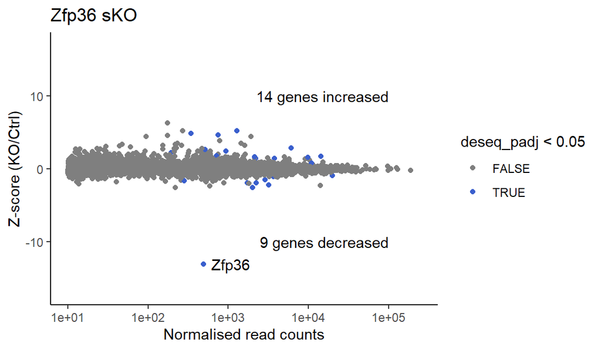

```r
TTP_sKO_intensity_diff %>%
  ggplot(aes(x = average.intensity, y = z.score)) +
    geom_point(aes(colour = deseq_padj < 0.05)) +
    scale_x_log10(breaks =c(10,100,1000,10000,100000)) +
    scale_colour_manual(values = c("grey50","royalblue3")) +
    coord_cartesian(xlim = c(10,250000), ylim= c(-17,17)) +
    geom_text(data = filter(TTP_sKO_intensity_diff, Gene == "Zfp36"), aes(label = Gene), hjust = 0, nudge_x = 0.1) +
    labs(title = "Zfp36 sKO", x = "Normalised read counts", y = "Z-score (KO/Ctrl)") +
    annotate("text", x = 100000, y = c(-10,10), label = c(paste(nrow(filter(TTP_sKO_intensity_diff, deseq_padj < 0.05 & z.score < 0)), "genes decreased"), paste(nrow(filter(TTP_sKO_intensity_diff, deseq_padj < 0.05 & z.score > 0)), "genes increased")), hjust = 1)
```

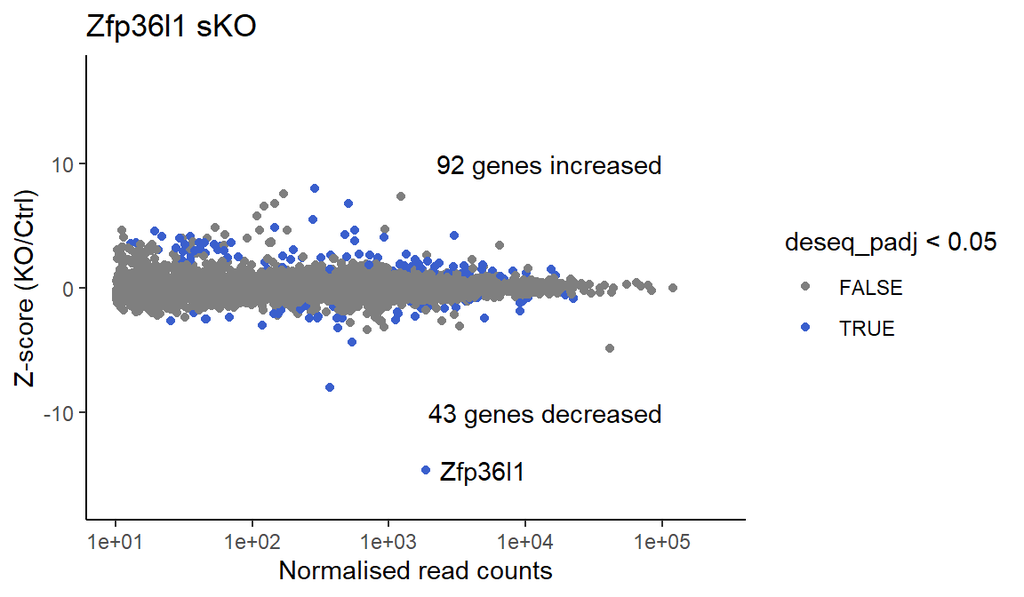

```r
ggsave("Figure_panels/FigS1C_Zfp36_zscore.pdf")
Tis11b_sKO_intensity_diff %>%
  ggplot(aes(x = average.intensity, y = z.score)) +
    geom_point(aes(colour = deseq_padj < 0.05)) +
    scale_x_log10(breaks =c(10,100,1000,10000,100000)) +
    scale_colour_manual(values = c("grey50","royalblue3")) +
    coord_cartesian(xlim = c(10,250000), ylim= c(-17,17)) +
    geom_text(data = filter(Tis11b_sKO_intensity_diff, Gene == "Zfp36l1"), aes(label = Gene), hjust = 0, nudge_x = 0.1) +
    labs(title = "Zfp36l1 sKO", x = "Normalised read counts", y = "Z-score (KO/Ctrl)") +
    annotate("text", x = 100000, y = c(-10,10), label = c(paste(nrow(filter(Tis11b_sKO_intensity_diff, deseq_padj < 0.05 & z.score < 0)), "genes decreased"), paste(nrow(filter(Tis11b_sKO_intensity_diff, deseq_padj < 0.05 & z.score > 0)), "genes increased")), hjust = 1)
```

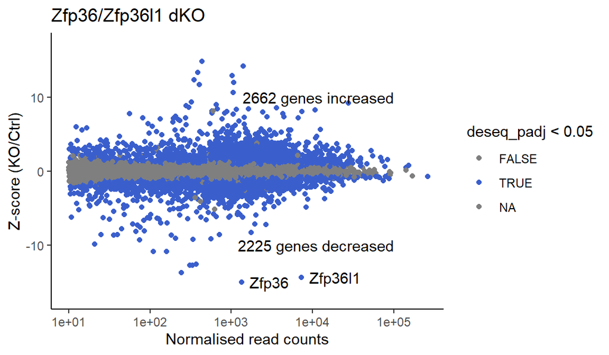

```r
ggsave("Figure_panels/FigS1D_Zfp36l1_zscore.pdf")
dKO_intensity_diff %>%
  ggplot(aes(x = average.intensity, y = z.score)) +
    geom_point(aes(colour = deseq_padj < 0.05)) +
    scale_x_log10(breaks =c(10,100,1000,10000,100000)) +
    scale_colour_manual(values = c("grey50","royalblue3")) +
    coord_cartesian(xlim = c(10,250000), ylim= c(-17,17)) +
    geom_text(data = filter(dKO_intensity_diff, Gene %in% c("Zfp36", "Zfp36l1")), aes(label = Gene), hjust = 0, nudge_x = 0.1) +
    labs(title = "Zfp36/Zfp36l1 dKO", x = "Normalised read counts", y = "Z-score (KO/Ctrl)") +
    annotate("text", x = 100000, y = c(-10,10), label = c(paste(nrow(filter(dKO_intensity_diff, deseq_padj < 0.05 & z.score < 0)), "genes decreased"), paste(nrow(filter(dKO_intensity_diff, deseq_padj < 0.05 & z.score > 0)), "genes increased")), hjust = 1)
```

```r
ggsave("Figure_panels/FigS1E_dKO_zscore.pdf")
```

### Table S1 - z-scores for single vs double KO comparison

Combine these into a single table, and show z-scores and DESeq2-derived p values/padj for genes that have padj < 0.05 for at least one comparison

```r
TTP_sKO_intensity_diff %>%
  left_join(Tis11b_sKO_intensity_diff, by = "Gene", suffix = c("_TTP", "_Tis11b")) %>%
  left_join(rename_with(dKO_intensity_diff, ~ paste0(.x, "_dKO")), by = c("Gene" = "Gene_dKO")) %>%
  select(Gene, starts_with("z.score"), starts_with("deseq")) -> sdKO_zscores_pvals

sdKO_zscores_pvals %>%
  select(Gene, contains("TTP"), contains("Tis"), contains("dKO")) %>%
  filter(if_any(contains("padj"), ~ 0.05 > .x)) %>%
  arrange(deseq_padj_dKO) %>%
  write_tsv("Supplementary_tables/TableS1_sdKO_zscores.txt")
```

## Nascent/4sU-labelled mRNA

For nascent, replicates 1 and 2 were done independently and should be included as a batch effect.

In this dataset, I have counts for the total, labelled (nascent) and unlabelled (pre-existing) fractions. For nascent RNA, I can simply run DESeq2 on the counts from the nascent fraction. But for estimating stability, I will also need normalised read counts for pre-existing and total fractions so run DESeq2 for these as well (although no need to extract results, just norm counts)

```r
raw_counts_4sU <- Nascent_raw_counts_complete[,grepl("4sU",colnames(Nascent_raw_counts_complete))]
raw_counts_total <- Nascent_raw_counts_complete[,grepl("total",colnames(Nascent_raw_counts_complete))]
raw_counts_preEx <- Nascent_raw_counts_complete[,grepl("preEx",colnames(Nascent_raw_counts_complete))]

coldata_4sU <- data.frame(row.names = colnames(raw_counts_4sU),Genotype = factor(grepl("Ctrl",colnames(raw_counts_4sU)),levels = c(T,F),labels = c("Ctrl","KO")),Batch = factor(grepl("1",colnames(raw_counts_4sU)),levels = c(T,F),labels = c("A","B")))
coldata_total <- data.frame(row.names = colnames(raw_counts_total),Genotype = factor(grepl("Ctrl",colnames(raw_counts_total)),levels = c(T,F),labels = c("Ctrl","KO")),Batch = factor(grepl("1",colnames(raw_counts_total)),levels = c(T,F),labels = c("A","B")))
coldata_preEx <- data.frame(row.names = colnames(raw_counts_preEx),Genotype = factor(grepl("Ctrl",colnames(raw_counts_preEx)),levels = c(T,F),labels = c("Ctrl","KO")),Batch = factor(grepl("1",colnames(raw_counts_preEx)),levels = c(T,F),labels = c("A","B")))

DESeqDataSetFromMatrix(raw_counts_4sU, colData = coldata_4sU, design = ~Batch+Genotype) %>%
  DESeq() -> dds_4sU
DESeqDataSetFromMatrix(raw_counts_total, colData = coldata_total, design = ~Batch+Genotype) %>%
  DESeq() -> dds_total
DESeqDataSetFromMatrix(raw_counts_preEx, colData = coldata_preEx, design = ~Batch+Genotype) %>%
  DESeq() -> dds_preEx
counts(dds_4sU, normalized = T) %>%
  as_tibble(rownames = "Gene") -> norm_counts_4sU
counts(dds_total, normalized = T) %>%
  as_tibble(rownames = "Gene") -> norm_counts_total
counts(dds_preEx, normalized = T) %>%
  as_tibble(rownames = "Gene") -> norm_counts_preEx

dds_4sU %>%
  lfcShrink(coef = 3, type = "normal") %>%
  as_tibble(rownames = "Gene") -> res_4sU
```

```
## using 'normal' for LFC shrinkage, the Normal prior from Love et al (2014).
##
## Note that type='apeglm' and type='ashr' have shown to have less bias than type='normal'.
## See ?lfcShrink for more details on shrinkage type, and the DESeq2 vignette.
## Reference: https://doi.org/10.1093/bioinformatics/bty895
```

### Table S3 - newly synthesised DE genes

Export significantly altered for supplemetary table - using padj < 0.1 for some analyses so include all of these.

```r
res_4sU %>%
  filter(baseMean > 10) %>%
  filter(padj < 0.1) %>%
  filter(log2FoldChange > 0) %>%
  arrange(padj) %>%
  write_tsv("Supplementary_tables/TableS3_4sUincreased.txt")

res_4sU %>%
  filter(baseMean > 10) %>%
  filter(padj < 0.1) %>%
  filter(log2FoldChange < 0) %>%
  arrange(padj) %>%
  write_tsv("Supplementary_tables/TableS3_4sUdecreased.txt")
```

## Stability

First need to calculate correction factors based on pre-existing, total and nascent normalised counts.

I will calculate these for each genotype/replicate separately, and then take the average.

For each, need the ratios between pre-existing:total and nascent:total, then fit a linear model between them. The coefficients from the linear model can then be used to calculate the correction factors (see supplementary methods from DOI: 10.1261/rna.1136108)

```r
norm_counts_4sU %>%
  left_join(norm_counts_preEx) %>%
  left_join(norm_counts_total) -> norm_counts_all_4sU
norm_counts_all_4sU$ratioPT_C1 <- norm_counts_all_4sU$Ctrl_preEx_1/norm_counts_all_4sU$Ctrl_total_1
norm_counts_all_4sU$ratioPT_C2 <- norm_counts_all_4sU$Ctrl_preEx_2/norm_counts_all_4sU$Ctrl_total_2
norm_counts_all_4sU$ratioPT_K1 <- norm_counts_all_4sU$KO_preEx_1/norm_counts_all_4sU$KO_total_1
norm_counts_all_4sU$ratioPT_K2 <- norm_counts_all_4sU$KO_preEx_2/norm_counts_all_4sU$KO_total_2

norm_counts_all_4sU$ratioNT_C1 <- norm_counts_all_4sU$Ctrl_4sU_1/norm_counts_all_4sU$Ctrl_total_1
norm_counts_all_4sU$ratioNT_C2 <- norm_counts_all_4sU$Ctrl_4sU_2/norm_counts_all_4sU$Ctrl_total_2
norm_counts_all_4sU$ratioNT_K1 <- norm_counts_all_4sU$KO_4sU_1/norm_counts_all_4sU$KO_total_1
norm_counts_all_4sU$ratioNT_K2 <- norm_counts_all_4sU$KO_4sU_2/norm_counts_all_4sU$KO_total_2


lm_4sU_C1 <- lm(ratioPT_C1 ~ ratioNT_C1, norm_counts_all_4sU[is.finite(norm_counts_all_4sU$ratioNT_C1 + norm_counts_all_4sU$ratioNT_C1),])
C1_Pnorm <- 1/lm_4sU_C1$coefficients[1]
C1_Nnorm <- -lm_4sU_C1$coefficients[2]*C1_Pnorm

lm_4sU_C2 <- lm(ratioPT_C2 ~ ratioNT_C2, norm_counts_all_4sU[is.finite(norm_counts_all_4sU$ratioNT_C2 + norm_counts_all_4sU$ratioNT_C2),])
C2_Pnorm <- 1/lm_4sU_C2$coefficients[1]
C2_Nnorm <- -lm_4sU_C2$coefficients[2]*C2_Pnorm

lm_4sU_K1 <- lm(ratioPT_K1 ~ ratioNT_K1, norm_counts_all_4sU[is.finite(norm_counts_all_4sU$ratioNT_K1 + norm_counts_all_4sU$ratioNT_K1),])
K1_Pnorm <- 1/lm_4sU_K1$coefficients[1]
K1_Nnorm <- -lm_4sU_K1$coefficients[2]*K1_Pnorm

lm_4sU_K2 <- lm(ratioPT_K2 ~ ratioNT_K2, norm_counts_all_4sU[is.finite(norm_counts_all_4sU$ratioNT_K2 + norm_counts_all_4sU$ratioNT_K2),])
K2_Pnorm <- 1/lm_4sU_K2$coefficients[1]
K2_Nnorm <- -lm_4sU_K2$coefficients[2]*K2_Pnorm

# then take average norm factor for newly transcribed to use below
norm_factor_newlyTranscribed <- median(c(C1_Nnorm, C2_Nnorm, K1_Nnorm, K2_Nnorm))
```

Now calculate relative stability from the nascent and total counts, using the correction factor calculated above

```r
norm_counts_all_4sU$Ctrl_relative_stability_1 <- -log(2)/(log(1-((norm_counts_all_4sU$Ctrl_4sU_1*norm_factor_newlyTranscribed)/norm_counts_all_4sU$Ctrl_total_1)))
norm_counts_all_4sU$Ctrl_relative_stability_2 <- -log(2)/(log(1-((norm_counts_all_4sU$Ctrl_4sU_2*norm_factor_newlyTranscribed)/norm_counts_all_4sU$Ctrl_total_2)))
norm_counts_all_4sU$KO_relative_stability_1 <- -log(2)/(log(1-((norm_counts_all_4sU$KO_4sU_1*norm_factor_newlyTranscribed)/norm_counts_all_4sU$KO_total_1)))
norm_counts_all_4sU$KO_relative_stability_2 <- -log(2)/(log(1-((norm_counts_all_4sU$KO_4sU_2*norm_factor_newlyTranscribed)/norm_counts_all_4sU$KO_total_2)))
norm_counts_all_4sU$Ctrl_log_stability_1 <- log2(norm_counts_all_4sU$Ctrl_relative_stability_1)
norm_counts_all_4sU$Ctrl_log_stability_2 <- log2(norm_counts_all_4sU$Ctrl_relative_stability_2)
norm_counts_all_4sU$KO_log_stability_1 <- log2(norm_counts_all_4sU$KO_relative_stability_1)
norm_counts_all_4sU$KO_log_stability_2 <- log2(norm_counts_all_4sU$KO_relative_stability_2)
```

NaNs are from 0s - will remove non-finite after calculating differences below.

Calculate difference between stability in KO vs Ctrl for the replicates separately (since there was a substantial batch effect between the two experiments), standardised to s.d. Then mean change in stability

```r
norm_counts_all_4sU$stability_shift_1 <- norm_counts_all_4sU$KO_log_stability_1 - norm_counts_all_4sU$Ctrl_log_stability_1
norm_counts_all_4sU$stability_shift_2 <- norm_counts_all_4sU$KO_log_stability_2 - norm_counts_all_4sU$Ctrl_log_stability_2

norm_counts_all_4sU$standardised_stability_shift_1 <- norm_counts_all_4sU$stability_shift_1/sd(norm_counts_all_4sU$stability_shift_1,na.rm = T)
norm_counts_all_4sU$standardised_stability_shift_2 <- norm_counts_all_4sU$stability_shift_2/sd(norm_counts_all_4sU$stability_shift_2,na.rm = T)

norm_counts_all_4sU$standardised_stability_shift_mean <- rowMeans(as.matrix(norm_counts_all_4sU[,grepl("standardised_stability_shift_[12]", colnames(norm_counts_all_4sU))]))

# create new dataframe containing stability differences, into which we'll add additional stats etc
Stability_differences <- data.frame(Gene = res_4sU$Gene)

Stability_differences$Stability_shift <- norm_counts_all_4sU$standardised_stability_shift_mean[match(Stability_differences$Gene, norm_counts_all_4sU$Gene)]

Stability_differences <- Stability_differences[is.finite(Stability_differences$Stability_shift),]
```

To identify statistically significant differences between KO and Ctrl, will use intensityDifference function (see intensityDifference.R). Originally by Simon Andrews (https://github.com/s-andrews/intensitydiff), version used here is modified to allow ‘averages’ and ‘differences’ to be provided directly, rather than calculated from separate data for Ctrl and KO.

It calculates z-scores for the differences based on the local standard deviation of the expression levels, since the amount of noise decreases as expression increases. Ie, low expressed genes are penalised more. In this case, we need to provide the averages and differences separately, because the averages are average stability, whilst the local standard deviation should be based on expression (since things with similar stability are not necessarily of similar expression level, and we wouldn’t expect any particular correlation between stability and noise). For the ‘averages’, I will use the mean normalised read counts across nascent (columns 2:5 in norm_counts_all_4sU) and total (columns 10:13 of norm_counts_all_4sU). For differences I will use the mean standardised stability shift calculated above.

Also used above for sKO vs dKO comparison

```r
Stability_differences$mean_total4sU <- rowMeans(norm_counts_all_4sU[match(Stability_differences$Gene, norm_counts_all_4sU$Gene), c(2:5, 10:13)])

Stability_differences <- cbind(Stability_differences, intensity.difference(averages = Stability_differences$mean_total4sU, differences = Stability_differences$Stability_shift))
```

### Table S4 - genes with altered stability

Export genes with absolute z-score > 2 for supplementary table

```r
Stability_differences %>%
  filter(average.intensity > 10) %>%
  filter(z.score > 2) %>%
  arrange(desc(z.score)) %>%
  select(Gene, mean_total4sU, Stability_shift, local.sd, p.value, fdr.value, z.score) %>%
  write_tsv("Supplementary_tables/TableS4_stabincreased.txt")

Stability_differences %>%
  filter(average.intensity > 10) %>%
  filter(z.score < -2) %>%
  arrange(z.score) %>%
  select(Gene, mean_total4sU, Stability_shift, local.sd, p.value, fdr.value, z.score) %>%
  write_tsv("Supplementary_tables/TableS4_stabdecreased.txt")
```

## Ribo-seq

For Riboseq, replicates were processed in 2 batches: replicates 1 and 2 in the first batch, and 3-5 in the second. This will be included in coldata and as a batch effect in the DESeq2 analysis.

```r
coldata_Ribo <- data.frame(row.names = colnames(Ribo_raw_counts_complete),Genotype = factor(grepl("WT",colnames(Ribo_raw_counts_complete)),levels = c(T,F),labels = c("Ctrl","KO")),Batch = factor(as.numeric(gsub(".*([0-9])$", "\\1", colnames(Ribo_raw_counts_complete))) %in% c(1,2),levels = c(T,F),labels = c("A","B")))

DESeqDataSetFromMatrix(Ribo_raw_counts_complete, colData = coldata_Ribo, design = ~Batch+Genotype) %>%
  DESeq() -> dds_Ribo
counts(dds_Ribo, normalized = T) %>%
  as_tibble(rownames = "Gene") -> norm_counts_Ribo

lfcShrink(dds_Ribo, coef = 3, type = "normal") %>%
  as_tibble(rownames = "Gene") -> res_Ribo
```

```
## using 'normal' for LFC shrinkage, the Normal prior from Love et al (2014).
##
## Note that type='apeglm' and type='ashr' have shown to have less bias than type='normal'.
## See ?lfcShrink for more details on shrinkage type, and the DESeq2 vignette.
## Reference: https://doi.org/10.1093/bioinformatics/bty895
```

### Table S5 - Riboseq DE genes

Export signficant genes for supplementary table

```r
res_Ribo %>%
  filter(baseMean > 10) %>%
  filter(padj < 0.05) %>%
  filter(log2FoldChange > 0) %>%
  arrange(padj) %>%
  write_tsv("Supplementary_tables/TableS5_Riboincreased.txt")

res_Ribo %>%
  filter(baseMean > 10) %>%
  filter(padj < 0.05) %>%
  filter(log2FoldChange < 0) %>%
  arrange(padj) %>%
  write_tsv("Supplementary_tables/TableS5_Ribodecreased.txt")
```

## Generate plots

I also want to highlight genes that are cytokines, so first read in list of cytokine/chemokine genes

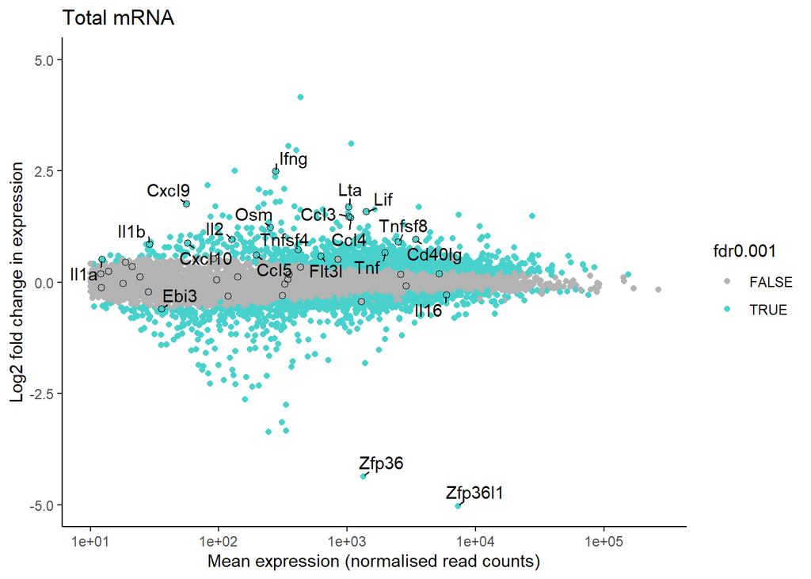

```r
Cytokine_genes <- read.table("Annotations/Cytokine_genes.txt")$V1

res_RNA %>%
  mutate(Cytokine = Gene %in% Cytokine_genes) -> res_RNA
res_4sU %>%
  mutate(Cytokine = Gene %in% Cytokine_genes) -> res_4sU
res_Ribo %>%
  mutate(Cytokine = Gene %in% Cytokine_genes) -> res_Ribo
Stability_differences %>%
  mutate(Cytokine = Gene %in% Cytokine_genes) -> Stability_differences

res_RNA %>%
  arrange(Cytokine) %>%
  filter(baseMean > 10 & !is.na(padj)) %>%
  ggplot(aes(x = baseMean, y = log2FoldChange)) +
    geom_point(aes(colour = padj < 0.001), size = 1.5) +
    geom_point(data = filter(res_RNA, baseMean > 10 & !is.na(padj) & Cytokine == TRUE), shape = 1, size = 1.8) +
    geom_text_repel(data = res_RNA[res_RNA$Gene %in% c(Cytokine_genes, "Zfp36","Zfp36l1") & res_RNA$padj < 0.001 & abs(res_RNA$log2FoldChange) > 0.25,], aes(label = Gene), min.segment.length = 0)  +
    scale_x_log10(breaks = c(10,100,1000,10000, 100000)) +
    scale_colour_manual(name = "fdr0.001",values = c("grey70","mediumturquoise")) +
    labs(title = "Total mRNA", x = "Mean expression (normalised read counts)", y = "Log2 fold change in expression") +
    coord_cartesian(ylim = c(-5,5))
```

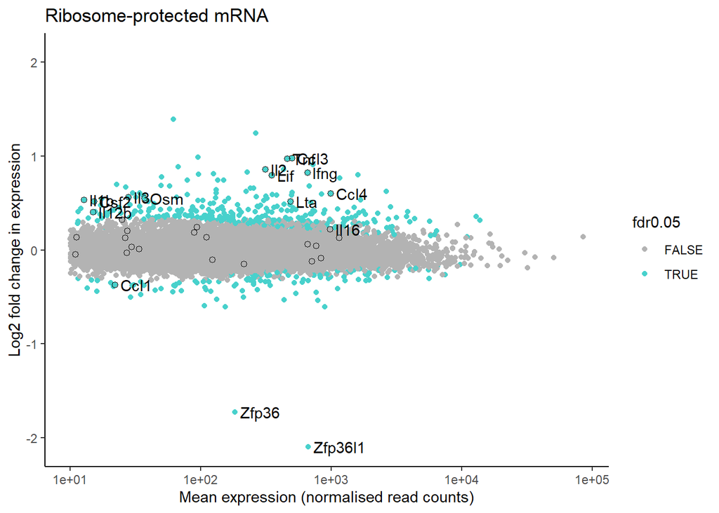

```r
ggsave("Figure_panels/Fig1A_MA_RNA.pdf", useDingbats = F)
res_Ribo %>%
  filter(baseMean > 10 & !is.na(padj)) %>%
  ggplot(aes(x = baseMean, y = log2FoldChange)) +
    geom_point(aes(colour = padj < 0.05), size = 1.5) +
    geom_point(data = filter(res_Ribo, baseMean > 10 & !is.na(padj) & Cytokine == TRUE), shape = 1, size = 1.8) +
    geom_text(data = res_Ribo[res_Ribo$Gene %in% c(Cytokine_genes, "Zfp36","Zfp36l1") & res_Ribo$padj < 0.05 & res_Ribo$baseMean > 10,], aes(label = Gene), hjust = 0, nudge_x = 0.04)  +
    scale_x_log10(breaks = c(10,100,1000,10000, 100000)) +
    scale_colour_manual(name = "fdr0.05",values = c("grey70","mediumturquoise")) +
    labs(title = "Ribosome-protected mRNA", x = "Mean expression (normalised read counts)", y = "Log2 fold change in expression") +
    coord_cartesian(ylim = c(-2.1,2.1))
```

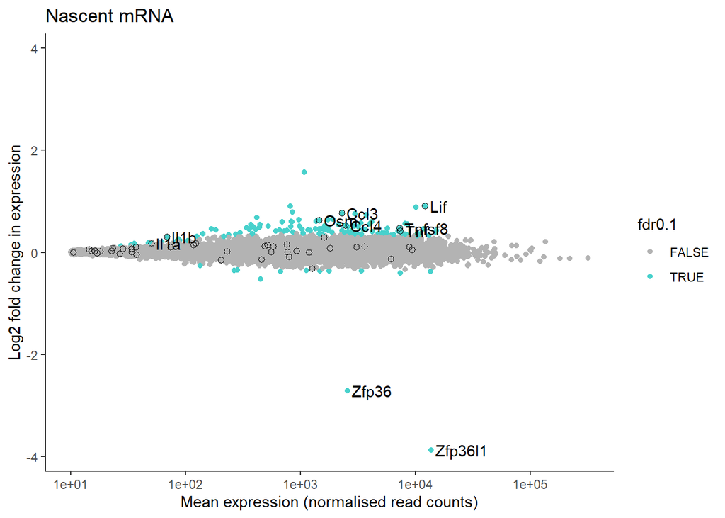

```r
ggsave("Figure_panels/Fig1D_MA_Ribo.pdf", useDingbats = F)
res_4sU %>%
  filter(baseMean > 10 & !is.na(padj)) %>%
    ggplot(aes(x = baseMean, y = log2FoldChange)) +
      geom_point(aes(colour = padj < 0.1), size = 1.5) +
      geom_point(data = filter(res_4sU, baseMean > 10 & !is.na(padj) & Cytokine == TRUE), shape = 1, size = 1.8) +
      geom_text(data = res_4sU[res_4sU$Gene %in% c(Cytokine_genes, "Zfp36","Zfp36l1") & res_4sU$padj < 0.1,], aes(label = Gene), hjust = 0, nudge_x = 0.04)  +
      scale_x_log10(breaks = c(10,100,1000,10000, 100000)) +
      scale_colour_manual(name = "fdr0.1", values = c("grey70","mediumturquoise"))  +
      labs(title = "Nascent mRNA", x = "Mean expression (normalised read counts)", y = "Log2 fold change in expression") +
      coord_cartesian(ylim = c(-3.9,3.9))
```

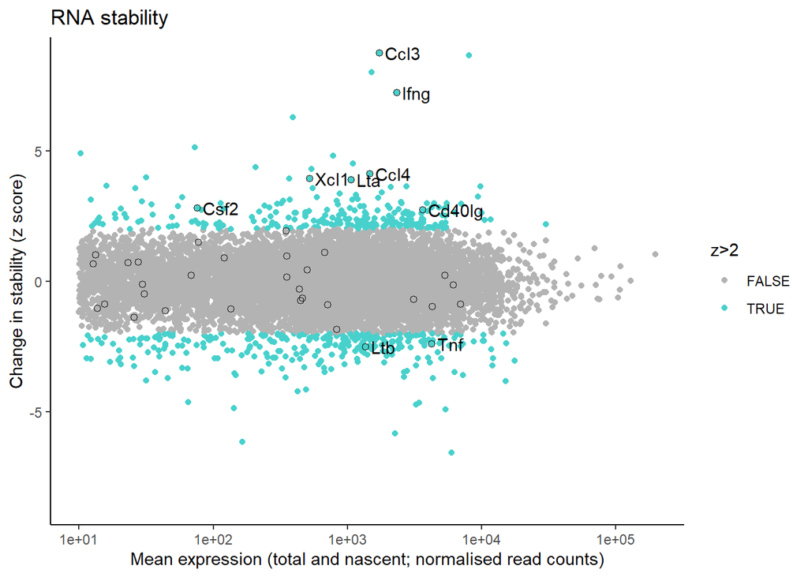

```r
ggsave("Figure_panels/Fig1B_MA_4sU.pdf", useDingbats = F)
Stability_differences %>%
  filter(average.intensity > 10) %>%
    ggplot(aes(x = mean_total4sU, y = z.score)) +
      geom_point(aes(colour = abs(z.score) > 2))  +
      geom_point(data = filter(Stability_differences, average.intensity > 10 & Cytokine == TRUE), shape = 1, size = 1.8) +
      scale_x_log10(breaks = c(10,100,1000,10000, 100000)) +
      scale_colour_manual(name = "z>2",values = c("grey70","mediumturquoise"))+
      geom_text(data = Stability_differences[Stability_differences$Cytokine == T & abs(Stability_differences$z.score) > 2,], aes(label = Gene), hjust = 0, colour = "black", nudge_x = 0.04)  +
      labs(title = "RNA stability", x = "Mean expression (total and nascent; normalised read counts)", y = "Change in stability (z score)") +
      coord_cartesian(ylim = c(-8.5,8.5))
```

```r
ggsave("Figure_panels/Fig1C_MA_stability.pdf", useDingbats = F)
```

# Figure 1E - TNF, IFNg and IL2 measurements

Read in graphpad files, combine and convert to long format with appropriate grouping columns

```r
as_tibble(read_pzfx("timecourse_RNA_protein/150409 RNA+protein IL2,TNF,IFNg CD4-AB wt&cKO 0-96h.pzfx", "TNF RNA")) %>%
  add_column(Cytokine = "TNF", Dataset = "RNA") ->
    TNF_IFNg_IL2

as_tibble(read_pzfx("timecourse_RNA_protein/150409 RNA+protein IL2,TNF,IFNg CD4-AB wt&cKO 0-96h.pzfx", "IFNg RNA")) %>%
  add_column(Cytokine = "IFNg", Dataset = "RNA") %>%
  bind_rows(TNF_IFNg_IL2) ->
    TNF_IFNg_IL2

as_tibble(read_pzfx("timecourse_RNA_protein/150409 RNA+protein IL2,TNF,IFNg CD4-AB wt&cKO 0-96h.pzfx", "TNF protein")) %>%
  add_column(Cytokine = "TNF", Dataset = "Protein") %>%
  bind_rows(TNF_IFNg_IL2) ->
    TNF_IFNg_IL2

as_tibble(read_pzfx("timecourse_RNA_protein/150409 RNA+protein IL2,TNF,IFNg CD4-AB wt&cKO 0-96h.pzfx", "IFNg protein")) %>%
  add_column(Cytokine = "IFNg", Dataset = "Protein") %>%
  bind_rows(TNF_IFNg_IL2) ->
    TNF_IFNg_IL2

as_tibble(read_pzfx("timecourse_RNA_protein/150409 RNA+protein IL2,TNF,IFNg CD4-AB wt&cKO 0-96h.pzfx", "IL2 RNA")) %>%
  add_column(Cytokine = "IL2", Dataset = "RNA") %>%
  bind_rows(TNF_IFNg_IL2) ->
    TNF_IFNg_IL2

as_tibble(read_pzfx("timecourse_RNA_protein/150409 RNA+protein IL2,TNF,IFNg CD4-AB wt&cKO 0-96h.pzfx", "IL2 protein")) %>%
  add_column(Cytokine = "IL2", Dataset = "Protein") %>%
  bind_rows(TNF_IFNg_IL2) ->
    TNF_IFNg_IL2


TNF_IFNg_IL2 %>%
  pivot_longer(-c(Cytokine, Dataset), names_to = "Sample", values_to = "Quantity") %>%
    mutate(Time = sub(".* (.*?)_.*", "\\1", Sample)) %>%
    mutate(Genotype = factor(grepl("wt", Sample), levels = c(T,F), labels = c("Ctrl", "dKO"))) %>%
    mutate(Dataset = factor(Dataset, levels = c("RNA", "Protein"))) %>%
    mutate(Cytokine = factor(Cytokine, levels = c("IFNg", "TNF", "IL2"))) ->
      TNF_IFNg_IL2
```

Normalise to mean quantity in controls at 0h. This can only be done for RNA - protein levels are 0 for both cytokines at 0h, so leave these are they are.

```r
TNF_IFNg_IL2 %>%
  group_by(Dataset, Cytokine, Genotype, Time) %>%
  summarise(mean_quantity = mean(Quantity)) %>%
  ungroup %>%
  unite(Condition, Dataset, Cytokine, Genotype, Time) ->
    TNF_IFNg_IL2_mean
TNF_IFNg_IL2 %>%
  mutate(Quantity_normMean = case_when(
    Dataset == "RNA" & Cytokine == "IFNg" ~ Quantity/TNF_IFNg_IL2_mean$mean_quantity[TNF_IFNg_IL2_mean$Condition == "RNA_IFNg_Ctrl_0h"],
    Dataset == "RNA" & Cytokine == "TNF" ~ Quantity/TNF_IFNg_IL2_mean$mean_quantity[TNF_IFNg_IL2_mean$Condition == "RNA_TNF_Ctrl_0h"],
    Dataset == "RNA" & Cytokine == "IL2" ~ Quantity/TNF_IFNg_IL2_mean$mean_quantity[TNF_IFNg_IL2_mean$Condition == "RNA_IL2_Ctrl_0h"],
    TRUE ~ Quantity
  )) ->
  TNF_IFNg_IL2
```

Plot on log scale. For protein, there are 0 values - convert these to 1 but plot as downward facing triangles to indicate they are off the scale.

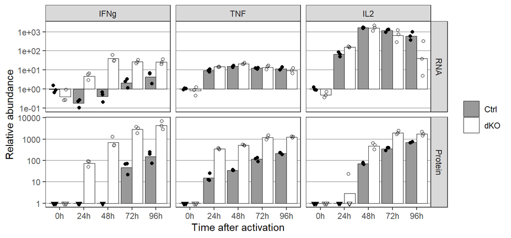

```r
TNF_IFNg_IL2 %>%
  mutate(Genotype_no0 = case_when(
    Genotype == "Ctrl" & Quantity == 0 ~ "Ctrl_0",
    Genotype == "dKO" & Quantity == 0 ~ "dKO_0",
    TRUE ~ as.character(Genotype)
  )) %>%
  mutate(Genotype_no0 = factor(Genotype_no0, levels = c("Ctrl", "dKO", "Ctrl_0", "dKO_0"))) %>%
  mutate(Quantity_no0 = if_else(Quantity == 0, 1, Quantity_normMean)) %>%
  ggplot(aes(x = Time, y = Quantity_no0, shape = Genotype_no0, fill = Genotype, group = Genotype)) +
    stat_summary(geom = "bar", fun = "mean", position = position_dodge(width = 0.9), colour = "black", size = 0.3) +
    geom_point(position = position_jitterdodge(dodge.width = 0.9), fill = "black") +
    facet_grid(Dataset ~ Cytokine, scales = "free") +
    theme_bw() +
    scale_fill_manual(values = c("grey60", "white")) +
    scale_shape_manual(guide = "none", values = c(19,1, 25, 6)) +
    theme(legend.background = element_blank(), legend.title = element_blank(), panel.grid = element_blank()) +
    labs(x = "Time after activation", y = "Relative abundance") +
    scale_y_log10() +
    theme(panel.grid.major.y = element_line(colour = "grey70"), legend.background = element_blank(), legend.key = element_blank())
```

```r
ggsave("Figure_panels/Fig1E_IFNgTNFIL2_measurements.pdf")
```

# Figure 2A-B - clustered heatmap

Make combined L2FC for each (or z-scores for stability) into a single dataframe.

For all except stability (which are already z-scores), calculate z-scores based on overall standard deviation. Since these are shrunken L2FC, the increased noise at low expression levels is already taken into account so no need to use local s.d. for this.

```r
all_fold_change <- data.frame(Gene = res_RNA$Gene, RNA_L2FC = res_RNA$log2FoldChange)

all_fold_change$Ribo_L2FC <- res_Ribo$log2FoldChange[match(all_fold_change$Gene, res_Ribo$Gene)]
all_fold_change$Nascent_L2FC <- res_4sU$log2FoldChange[match(all_fold_change$Gene, res_4sU$Gene)]
all_fold_change$Stability_change <- Stability_differences$z.score[match(all_fold_change$Gene, Stability_differences$Gene)]


all_L2FC_norm <- data.frame(Gene = all_fold_change$Gene, RNA_zscore = all_fold_change$RNA_L2FC/sd(all_fold_change$RNA_L2FC, na.rm = T), Ribo_zscore = all_fold_change$Ribo_L2FC/sd(all_fold_change$Ribo_L2FC, na.rm = T), Nascent_zscore= all_fold_change$Nascent_L2FC/sd(all_fold_change$Nascent_L2FC, na.rm = T), Stability_zscore = all_fold_change$Stability_change)
```

Since the different datasets have very different sensitivity in detecting significant differences (it might also be in part that there are more differences in RNA abundance than in the other measures - but the nascent and RiboSeq datasets also look generally more noisy), I will use different thresholds for each dataset to decide which genes to include in this analysis. This is so that we have representation of a reasonably large set of genes that show the greatest evidence for changing in each of the measures. The chosen thresholds are:

- Nascent mRNA - adjusted p value < 0.1
- Stability - z score > 2
- mRNA abundance - adjusted p value < 0.001
- Ribosome protected mRNA - adjusted p value < 0.05

I will exclude Zfp36/l1 (which have an apparent increase in stability); also exclude any gene which does not have a finite L2FC for all the measures.

Clustering for genes is done on z-scores, only including nascent, stability and Riboseq (since these are the most mechanistically interesting), and uses 1-correlation coefficient as a distance metric (datasets are not clustered).

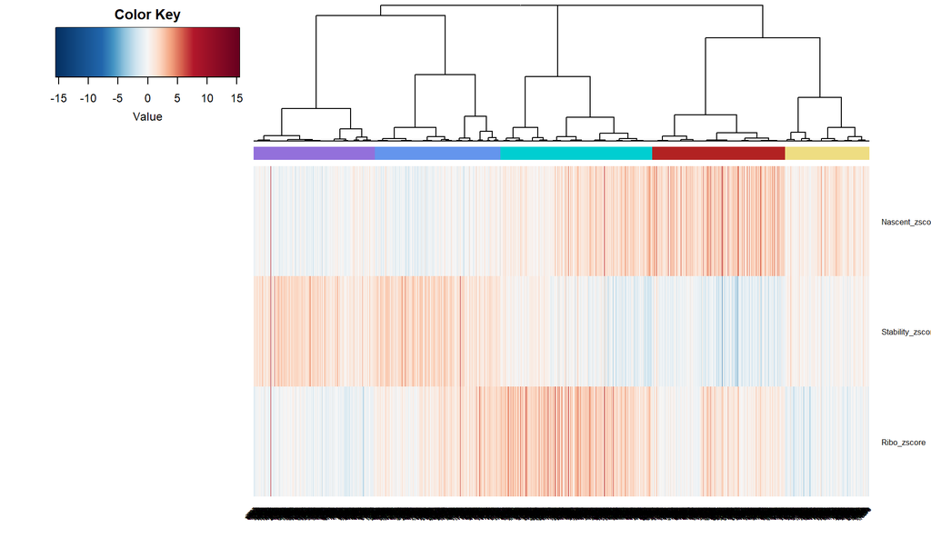

```r
up_all_L2FC <- all_L2FC_norm[all_L2FC_norm$Gene %in% c(res_RNA$Gene[res_RNA$padj < 0.001 & res_RNA$log2FoldChange > 0 & res_RNA$baseMean > 10], res_4sU$Gene[res_4sU$padj < 0.1 & res_4sU$log2FoldChange > 0 & res_4sU$baseMean > 10],  res_Ribo$Gene[res_Ribo$padj < 0.05 & res_Ribo$log2FoldChange > 0 & res_Ribo$baseMean > 10],  Stability_differences$Gene[Stability_differences$z.score > 2 & Stability_differences$average.intensity > 10]),c(1:5)]

up_all_L2FC <- up_all_L2FC[!up_all_L2FC$Gene %in% c("Zfp36", "Zfp36l1"),]
up_all_L2FC <- na.omit(up_all_L2FC)

up_all_cor <- cor(t(up_all_L2FC[,3:5]))

up_all_distCor <- as.dist(1-up_all_cor)

up_all_hcCor <- hclust(up_all_distCor)
up_all_L2FC$clustersCor <- cutree(up_all_hcCor,5)
up_all_L2FC$clusterColCor <- as.character(factor(up_all_L2FC$clustersCor, levels = c(1:5), labels =c("cornflowerblue","mediumpurple", "firebrick", "darkturquoise", "lightgoldenrod")))

up_all_L2FC_hm <- up_all_L2FC[,3:5]

#pdf("Figure_panels/Fig2A_clustered_heatmap.pdf", height=6, width=10)
heatmap.2(t(up_all_L2FC_hm[,c(2,3,1)]), Colv = as.dendrogram(up_all_hcCor), Rowv = F, col = c(colorRampPalette(colors = brewer.pal(11,"RdBu")[11:10])(100),colorRampPalette(colors = brewer.pal(11,"RdBu")[10:2])(200),colorRampPalette(colors = brewer.pal(11,"RdBu")[2:1])(100)), density.info = "none", cexRow = 0.8, trace = "none", symkey = T, symbreaks = T, ColSideColors = up_all_L2FC$clusterColCor, srtCol = 45)
```

```r
#dev.off()
```

Order of clusters in heatmap is: mediumpurple -> cornflowerblue -> darkturquoise -> firebrick -> lightgoldenrod

Reassign cluster numbers so they are numbered from 1 -> 5 left to right

```r
up_all_L2FC$clustersCor <- factor(up_all_L2FC$clusterColCor, levels = c("mediumpurple", "cornflowerblue", "darkturquoise", "firebrick", "lightgoldenrod"), labels= c(1,2,3,4,5))
```

Plot boxplot just for RNA abundance - include this plus simple table above which summarises the other measurements.

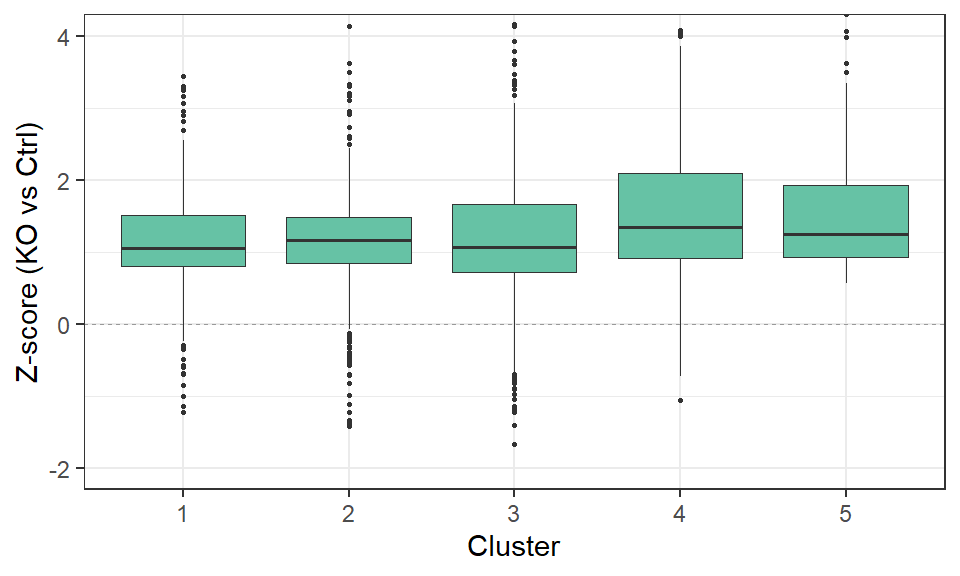

```r
up_all_L2FC %>%
  pivot_longer(2:5, names_to = "Dataset", values_to = "Z_score") %>%
  rename(Cluster = clustersCor) %>%
  filter(Dataset == "RNA_zscore") %>%
  ggplot(aes(x = Cluster, y = Z_score)) +
    geom_hline(yintercept = 0, colour ="grey60", linetype = "dashed", size = 0.3) +
    geom_boxplot(size = 0.3, outlier.size = 0.5, fill = brewer.pal(4, "Set2")[1]) +
    labs(y = "Z-score (KO vs Ctrl)") +
    theme_bw() +
    theme(panel.background = element_blank(), plot.background = element_blank()) +
    coord_cartesian(ylim = c(-2,4))
```

```r
ggsave("Figure_panels/Fig2B_clusters_RNAboxplot.pdf", useDingbats = F)
```

Calculate median for each zscore for each of the clusters to help with summary table in 1B

```r
up_all_L2FC %>%
  split(up_all_L2FC$clustersCor) %>%
  lapply(summary)
```

```
## $`1`
##      Gene             RNA_zscore       Ribo_zscore       Nascent_zscore
##  Length:349         Min.   :-2.3984   Min.   :-4.06350   Min.   :-2.6813
##  Class :character   1st Qu.: 0.8038   1st Qu.:-0.78479   1st Qu.:-0.5758
##  Mode  :character   Median : 1.0476   Median :-0.38271   Median :-0.1660
##                     Mean   : 1.1597   Mean   :-0.39701   Mean   :-0.1642
##                     3rd Qu.: 1.5151   3rd Qu.: 0.04269   3rd Qu.: 0.2185
##                     Max.   : 5.4279   Max.   : 7.48032   Max.   : 7.5967
##  Stability_zscore  clustersCor clusterColCor
##  Min.   :-0.3670   1:349       Length:349
##  1st Qu.: 0.6902   2:  0       Class :character
##  Median : 1.2301   3:  0       Mode  :character
##  Mean   : 1.3706   4:  0
##  3rd Qu.: 2.0421   5:  0
##  Max.   : 8.7357
##
## $`2`
##      Gene             RNA_zscore       Ribo_zscore      Nascent_zscore
##  Length:362         Min.   :-1.4155   Min.   :-1.1281   Min.   :-3.9930
##  Class :character   1st Qu.: 0.8449   1st Qu.: 0.3197   1st Qu.:-0.6341
##  Mode  :character   Median : 1.1607   Median : 0.8423   Median :-0.1978
##                     Mean   : 1.1725   Mean   : 0.9663   Mean   :-0.2388
##                     3rd Qu.: 1.4880   3rd Qu.: 1.4973   3rd Qu.: 0.2332
##                     Max.   : 8.2446   Max.   : 6.3314   Max.   : 2.8791
##  Stability_zscore  clustersCor clusterColCor
##  Min.   :-0.3993   1:  0       Length:362
##  1st Qu.: 0.8711   2:362       Class :character
##  Median : 1.6296   3:  0       Mode  :character
##  Mean   : 1.6173   4:  0
##  3rd Qu.: 2.2106   5:  0
##  Max.   : 7.2222
##
## $`3`
##      Gene             RNA_zscore      Ribo_zscore      Nascent_zscore
##  Length:438         Min.   :-5.345   Min.   :-0.0293   Min.   :-1.649
##  Class :character   1st Qu.: 0.718   1st Qu.: 1.2893   1st Qu.: 0.495
##  Mode  :character   Median : 1.072   Median : 2.1579   Median : 1.003
##                     Mean   : 1.215   Mean   : 2.2664   Mean   : 1.253
##                     3rd Qu.: 1.657   3rd Qu.: 2.8724   3rd Qu.: 1.773
##                     Max.   :10.137   Max.   : 9.5360   Max.   : 7.758
```

[output cut: 24 more lines]

```
## $`5`
##      Gene             RNA_zscore      Ribo_zscore       Nascent_zscore
##  Length:243         Min.   :0.5612   Min.   :-4.03537   Min.   :-1.0141
##  Class :character   1st Qu.:0.9329   1st Qu.:-0.93076   1st Qu.: 0.2377
##  Mode  :character   Median :1.2461   Median :-0.48844   Median : 0.7063
##                     Mean   :1.5504   Mean   :-0.52683   Mean   : 0.8527
##                     3rd Qu.:1.9331   3rd Qu.:-0.05811   3rd Qu.: 1.2223
##                     Max.   :7.8398   Max.   : 1.38968   Max.   : 4.5158
##  Stability_zscore  clustersCor clusterColCor
##  Min.   :-1.7498   1:  0       Length:243
##  1st Qu.:-0.2312   2:  0       Class :character
##  Median : 0.1170   3:  0       Mode  :character
##  Mean   : 0.1639   4:  0
##  3rd Qu.: 0.5800   5:243
##  Max.   : 2.9685
```

# CLIP data processing for subsequent figures

Peaks were called using iCount, for the following:

- Individual replicates for each dataset (for 24h iCLIP, grouped high and low MW for the dataset where these were sequenced separately)
- Grouped replicates for each antibody (BRF1/2 and Tis11b) for the 24h iCLIP data
- Grouped replicates for both antibodies together for the 24h iCLIP data
- Grouped replicates for each of the 4h and 72h HITS-CLIP datasets

Individual replicates for the 24h iCLIP were very low in depth, so for this dataset, used only the grouped replicates for subsequent analysis.

Using the files containing all crosslink sites (ie not filtered for FDR < 0.05, but include an FDR column for downstream filtering), annotated the gene/feature type for each crosslink site with iCLIP_Genialis_feature_annotation.R script (https://github.com/LouiseMatheson/Process_CLIP_data). NB - with these files, the annotation done by iCount results in some being duplicated - remove these.

## Generate lists of 3’UTR targets for each dataset

Since depth is relatively low for the 24h iCLIP data, for this I will use the data grouped for each antibody, and designate a gene a target if there is a significant crosslink site (FDR < 0.05) within its 3’UTR for both antibodies (not necessarily the identical site)

```r
read_tsv("CLIP_data/BRF1_2_all_merged_grouped_scores_annotated.tsv.gz") %>%
  distinct(chromosome, start, strand, .keep_all = T) %>%
  filter(FDR < 0.05) %>%
  filter(Feature  == "UTR3") %>%
  distinct(Gene_ID) %>%
  bind_rows({
    read_tsv("CLIP_data/Tis11b_all_merged_grouped_scores_annotated.tsv.gz") %>%
      distinct(chromosome, start, strand, .keep_all = T) %>%
      filter(FDR < 0.05) %>%
      filter(Feature  == "UTR3") %>%
      distinct(Gene_ID)
  }) %>%
  group_by(Gene_ID) %>%
  summarise(nAntibodies = n()) %>%
  filter(nAntibodies == 2) %>%
  pull(Gene_ID) -> iCLIP_24h_3UTR_targets
```

For HITS-CLIP data, depth is much better, so for this use the individual replicate datasets, requiring an identical crosslink site to be significant in at least 2 replicates.

```r
read_tsv("CLIP_data/wt-4h-1_trimmed_single_scores_annotated.tsv.gz") %>%
  distinct(chromosome, start, strand, .keep_all = T) %>%
  add_column(Replicate = 1) %>%
  bind_rows({
    read_tsv("CLIP_data/wt-4h-2_trimmed_single_scores_annotated.tsv.gz") %>%
      distinct(chromosome, start, strand, .keep_all = T) %>%
      add_column(Replicate = 2)
  }) %>%
  bind_rows({
    read_tsv("CLIP_data/wt-4h-3_trimmed_single_scores_annotated.tsv.gz") %>%
      distinct(chromosome, start, strand, .keep_all = T) %>%
      add_column(Replicate = 3)
  }) %>%
  bind_rows({
    read_tsv("CLIP_data/wt-4h-4_trimmed_single_scores_annotated.tsv.gz") %>%
      distinct(chromosome, start, strand, .keep_all = T) %>%
      add_column(Replicate = 4)
  }) %>%
  bind_rows({
    read_tsv("CLIP_data/wt-4h-5_trimmed_single_scores_annotated.tsv.gz") %>%
      distinct(chromosome, start, strand, .keep_all = T) %>%
      add_column(Replicate = 5)
  }) %>%
  filter(FDR < 0.05) %>%
  filter(Feature == "UTR3") %>%
  group_by(chromosome, start, strand, Gene_ID, Feature) %>%
  summarise(nReplicates = n(), .groups = "drop") %>%
  filter(nReplicates >= 2) %>%
  distinct(Gene_ID) %>%
  deframe() -> Darnell_4h_3UTR_targets
read_tsv("CLIP_data/wt-3d-1_trimmed_single_scores_annotated.tsv.gz") %>%
  distinct(chromosome, start, strand, .keep_all = T) %>%
  add_column(Replicate = 1) %>%
  bind_rows({
    read_tsv("CLIP_data/wt-3d-2_trimmed_single_scores_annotated.tsv.gz") %>%
      distinct(chromosome, start, strand, .keep_all = T) %>%
      add_column(Replicate = 2)
  }) %>%
  bind_rows({
    read_tsv("CLIP_data/wt-3d-3_trimmed_single_scores_annotated.tsv.gz") %>%
      distinct(chromosome, start, strand, .keep_all = T) %>%
      add_column(Replicate = 3)
  }) %>%
  bind_rows({
    read_tsv("CLIP_data/wt-3d-4_trimmed_single_scores_annotated.tsv.gz") %>%
      distinct(chromosome, start, strand, .keep_all = T) %>%
      add_column(Replicate = 4)
  }) %>%
  filter(FDR < 0.05) %>%
  filter(Feature == "UTR3") %>%
  group_by(chromosome, start, strand, Gene_ID, Feature) %>%
  summarise(nReplicates = n(), .groups = "drop") %>%
  filter(nReplicates >= 2) %>%
  distinct(Gene_ID) %>%
  deframe() -> Darnell_72h_3UTR_targets
```

## Summary per gene

As well as lists of targets, for some later analyses we want to use a summarised value for the 3’UTR of each genes. For this, I will use peaks called from the merged data across all replicates for each of the CLIP datasets, and calculate the sum of crosslinks over the 3’UTR, but only taking into account the crosslink sites with FDR < 0.25.

Since the datasets have quite different coverage, I will normalise to the 90th percentile for each dataset (only taking into account genes with score > 0, ie those that remain after filtering for FDR < 0.25)

```r
read_tsv("CLIP_data/BRF1_2_Tis11b_all_merged_grouped_scores_annotated.tsv.gz") %>%
  distinct(chromosome, start, strand, .keep_all = T) %>%
  filter(FDR < 0.25) %>%
  filter(Feature == "UTR3") %>%
  group_by(Gene_name) %>%
  summarise(sum_3UTR_24h = sum(score), Gene_ID = Gene_ID[1]) -> iCLIP_24h_3UTR_sum
iCLIP_24h_3UTR_sum %>%
  mutate(sum_3UTR_24h_n90 = sum_3UTR_24h/quantile(iCLIP_24h_3UTR_sum$sum_3UTR_24h, 0.9)) -> iCLIP_24h_3UTR_sum


read_tsv("CLIP_data/WT_4h_merged_grouped_scores_annotated.tsv.gz") %>%
  distinct(chromosome, start, strand, .keep_all = T) %>%
  filter(FDR < 0.25) %>%
  filter(Feature == "UTR3") %>%
  group_by(Gene_name) %>%
  summarise(sum_3UTR_4h = sum(score), Gene_ID = Gene_ID[1]) -> CLIP_4h_3UTR_sum
CLIP_4h_3UTR_sum %>%
  mutate(sum_3UTR_4h_n90 = sum_3UTR_4h/quantile(CLIP_4h_3UTR_sum$sum_3UTR_4h, 0.9)) -> CLIP_4h_3UTR_sum


read_tsv("CLIP_data/WT_3d_merged_grouped_scores_annotated.tsv.gz") %>%
  distinct(chromosome, start, strand, .keep_all = T) %>%
  filter(FDR < 0.25) %>%
  filter(Feature == "UTR3") %>%
  group_by(Gene_name) %>%
  summarise(sum_3UTR_72h = sum(score), Gene_ID = Gene_ID[1]) -> CLIP_72h_3UTR_sum
CLIP_72h_3UTR_sum %>%
  mutate(sum_3UTR_72h_n90 = sum_3UTR_72h/quantile(CLIP_72h_3UTR_sum$sum_3UTR_72h, 0.9)) -> CLIP_72h_3UTR_sum
```

## Table S7 - CLIP targets

Rather than having all the 4h targets first, then 24h etc, will reorganise to be genomic order

Import GTF file to use to covert gene IDs back to names (and for eg 3’UTR lengths later).

```r
import("Annotations/Mus_musculus.GRCm38.90.gtf.gz") -> GRCm38_90_gtf

Darnell_4h_3UTR_targets %>%
  as_tibble_col(column_name = "Gene_ID") %>%
  add_column(CLIP_4h = "Target") %>%
  full_join({
    iCLIP_24h_3UTR_targets %>%
      as_tibble_col(column_name = "Gene_ID") %>%
      add_column(CLIP_24h = "Target")
  }) %>%
  full_join({
    Darnell_72h_3UTR_targets %>%
      as_tibble_col(column_name = "Gene_ID") %>%
      add_column(CLIP_72h = "Target")
  }) %>%
  mutate(Gene_name = GRCm38_90_gtf$gene_name[match(Gene_ID, GRCm38_90_gtf$gene_id)]) %>%
  left_join(CLIP_4h_3UTR_sum) %>%
  left_join(iCLIP_24h_3UTR_sum) %>%
  left_join(CLIP_72h_3UTR_sum) %>%
  mutate(chromosome = as.factor(seqnames(GRCm38_90_gtf))[match(Gene_ID, GRCm38_90_gtf$gene_id)]) %>%
  mutate(start = ranges(GRCm38_90_gtf)@start[match(Gene_ID, GRCm38_90_gtf$gene_id)]) %>%
  arrange(chromosome, start) %>%
  select(Gene_name, Gene_ID, sum_3UTR_4h, sum_3UTR_24h, sum_3UTR_72h, ends_with("90"), starts_with("CLIP")) %>%
  mutate(across(starts_with("sum"), ~ if_else(is.na(.x), 0, .x))) %>%
  mutate(across(starts_with("CLIP"), ~ if_else(is.na(.x), "Non-target", .x))) %>%
  write_tsv("Supplementary_tables/TableS7_CLIP.txt")
```

## Lengths of 3’UTRs

This is needed for expression/3’UTR length matching to generate control genes sets for each cluster.

I will sum up the 3’UTR lengths from isoforms with a CCDS, since these are more confident.

Needs to be in a dataframe, with gene names as row names, and a single column containing the 3’UTR lengths. Object should be named UTR_lengths (this is what the script for expression matching expects)

```r
GRCm38_90_gtf[GRCm38_90_gtf$type == "three_prime_utr" & !is.na(GRCm38_90_gtf$ccds_id)] -> gene_3UTRs
split(gene_3UTRs, gene_3UTRs$gene_id) %>%
  GenomicRanges::reduce() %>%
  width() %>%
  sum() %>%
  enframe(value = "UTR_length") %>%
  column_to_rownames("name") -> UTR_lengths
```

## FPKMs

I also need to provide FPKM, log2-transformed, to be used for the expression matching.

These were generated for control samples from 24h iCLIP data, and for RNA-seq corresponding to the two HITS-CLIP datasets (from GSE96050), using cuffnorm and the GRCm38v90 annotation.

Need dataframes containing the log2-transformed FPKM for each replicate, with gene names as row names.

Add 1e-8 to all FPKM before log transforming to deal with 0s (lowest FPKM that are not 0 look to be > 1e-7).

The expression matching script will exclude any genes from the clusters that are not present in both the 3’UTR and expression dataframes, so it will not pose a problem if some are missing - they will just be ignored: CLIP targets/AREs will not be counted for that gene, and a control gene will not be selected.

```r
read_tsv("FPKM/iCLIP24h_genes.fpkm_table") %>%
  column_to_rownames("tracking_id") %>%
  mutate(across(everything(), ~ log2(.x + 1e-8))) %>%
  filter(if_all(everything(), is.finite)) -> CD4_24h_FPKM
read_tsv("FPKM/CLIP4h_genes.fpkm_table") %>%
  column_to_rownames("tracking_id") %>%
  mutate(across(everything(), ~ log2(.x + 1e-8))) %>%
  filter(if_all(everything(), is.finite)) -> CD4_4h_FPKM
read_tsv("FPKM/CLIP72h_genes.fpkm_table") %>%
  column_to_rownames("tracking_id") %>%
  mutate(across(everything(), ~ log2(.x + 1e-8))) %>%
  filter(if_all(everything(), is.finite)) -> CD4_72h_FPKM
```

Need to export 3 RData files, containing the 3’UTR lengths, log2 FPKM and CLIP targets for the 24h iCLIP, 4h and 72h HITS-CLIP datasets

For each, the script expects the CLIP targets to be called iCLIP_3UTR_hits, and the FPKM to be called Expression_norm_per_kb.

So need to rename each in turn before saving out the RData files.

```r
Expression_norm_per_kb <- CD4_24h_FPKM
iCLIP_3UTR_hits <- iCLIP_24h_3UTR_targets
save(Expression_norm_per_kb, iCLIP_3UTR_hits, UTR_lengths, file = "CLIP_data/iCLIP_24h_exMatch.RData")

Expression_norm_per_kb <- CD4_4h_FPKM
iCLIP_3UTR_hits <- Darnell_4h_3UTR_targets
save(Expression_norm_per_kb, iCLIP_3UTR_hits, UTR_lengths, file = "CLIP_data/CLIP_4h_exMatch.RData")

Expression_norm_per_kb <- CD4_72h_FPKM
iCLIP_3UTR_hits <- Darnell_72h_3UTR_targets
save(Expression_norm_per_kb, iCLIP_3UTR_hits, UTR_lengths, file = "CLIP_data/CLIP_72h_exMatch.RData")
```

Check how well expression between the different timepoints/conditions correlates

```r
read_tsv("FPKM/iCLIP24h_genes.fpkm_table") %>%
  mutate(across(where(is.numeric), ~ log2(.x + 1e-8))) %>%
  mutate(FPKM_24h = rowMeans(select(., is.numeric))) %>%
  select(tracking_id, FPKM_24h) %>%
  inner_join({
    read_tsv("FPKM/CLIP4h_genes.fpkm_table") %>%
      mutate(across(where(is.numeric), ~ log2(.x + 1e-8))) %>%
      mutate(FPKM_4h = rowMeans(select(., is.numeric))) %>%
      select(tracking_id, FPKM_4h)
  }) %>%
  inner_join({
    read_tsv("FPKM/CLIP72h_genes.fpkm_table") %>%
      mutate(across(where(is.numeric), ~ log2(.x + 1e-8))) %>%
      mutate(FPKM_72h = rowMeans(select(., is.numeric))) %>%
      select(tracking_id, FPKM_72h)
  }) -> FPKM_all_CLIPdata
```

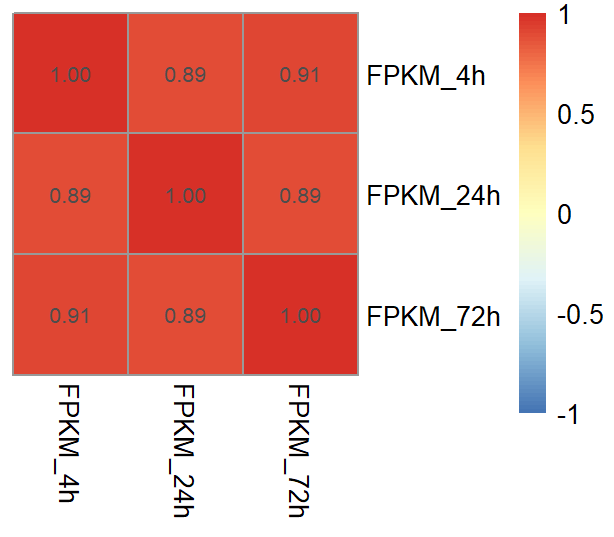

```r
FPKM_all_CLIPdata %>%
  select(FPKM_4h, FPKM_24h, FPKM_72h) %>%
  cor() %>%
  pheatmap(
    cluster_cols = F,
    cluster_rows = F,
    breaks = seq(-1,1, length.out = 101),
    display_numbers = T
  )
```

# Figure 2C-D - CLIP and ARE enrichment

## Export gene lists for each cluster

For these, I will use gene IDs (as I have for FPKM/CLIP targets/3’UTR lengths above) as they are more stable

```r
up_all_L2FC %>%
  filter(clustersCor == "1") %>%
  mutate(Gene_ID = GRCm38_90_gtf$gene_id[match(Gene, GRCm38_90_gtf$gene_name)]) %>%
  pull(Gene_ID) %>%
  write("Clusters/cluster1.txt")
up_all_L2FC %>%
  filter(clustersCor == "2") %>%
  mutate(Gene_ID = GRCm38_90_gtf$gene_id[match(Gene, GRCm38_90_gtf$gene_name)]) %>%
  pull(Gene_ID) %>%
  write("Clusters/cluster2.txt")
up_all_L2FC %>%
  filter(clustersCor == "3") %>%
  mutate(Gene_ID = GRCm38_90_gtf$gene_id[match(Gene, GRCm38_90_gtf$gene_name)]) %>%
  pull(Gene_ID) %>%
  write("Clusters/cluster3.txt")
up_all_L2FC %>%
  filter(clustersCor == "4") %>%
  mutate(Gene_ID = GRCm38_90_gtf$gene_id[match(Gene, GRCm38_90_gtf$gene_name)]) %>%
  pull(Gene_ID) %>%
  write("Clusters/cluster4.txt")
up_all_L2FC %>%
  filter(clustersCor == "5") %>%
  mutate(Gene_ID = GRCm38_90_gtf$gene_id[match(Gene, GRCm38_90_gtf$gene_name)]) %>%
  pull(Gene_ID) %>%
  write("Clusters/cluster5.txt")
```

## Enrichment for CLIP targets within each cluster

For each cluster, ran expression matching script (expression_match_iCLIP.R) against each of the three RData files corresponding to each of the CLIP datasets. Eg: Rscript –vanilla expression_match_iCLIP.R cluster1.txt iCLIP_24h_exMatch.RData

This creates 100 sets of expression/3’UTR length matched controls for the input gene set (ie, the genes in a given cluster), and identifies the CLIP targets within both the gene set of interest, and the control sets. Also calculates the 5th and 95th percentiles for the number of overlaps in the control sets.

```r
list(
  readRDS("Clusters/cluster1_iCLIP_24h_exMatch_expressionMatch_processed_data.rds") %>%
  sapply(function(x) add_column(x, cluster = 1)),
  readRDS("Clusters/cluster2_iCLIP_24h_exMatch_expressionMatch_processed_data.rds") %>%
  sapply(function(x) add_column(x, cluster = 2)),
  readRDS("Clusters/cluster3_iCLIP_24h_exMatch_expressionMatch_processed_data.rds") %>%
  sapply(function(x) add_column(x, cluster = 3)),
  readRDS("Clusters/cluster4_iCLIP_24h_exMatch_expressionMatch_processed_data.rds") %>%
  sapply(function(x) add_column(x, cluster = 4)),
  readRDS("Clusters/cluster5_iCLIP_24h_exMatch_expressionMatch_processed_data.rds") %>%
  sapply(function(x) add_column(x, cluster = 5))
) -> all_clusters_24h_CLIP


list(
  readRDS("Clusters/cluster1_CLIP_4h_exMatch_expressionMatch_processed_data.rds") %>%
  sapply(function(x) add_column(x, cluster = 1)),
  readRDS("Clusters/cluster2_CLIP_4h_exMatch_expressionMatch_processed_data.rds") %>%
  sapply(function(x) add_column(x, cluster = 2)),
  readRDS("Clusters/cluster3_CLIP_4h_exMatch_expressionMatch_processed_data.rds") %>%
  sapply(function(x) add_column(x, cluster = 3)),
  readRDS("Clusters/cluster4_CLIP_4h_exMatch_expressionMatch_processed_data.rds") %>%
  sapply(function(x) add_column(x, cluster = 4)),
  readRDS("Clusters/cluster5_CLIP_4h_exMatch_expressionMatch_processed_data.rds") %>%
  sapply(function(x) add_column(x, cluster = 5))
) -> all_clusters_4h_CLIP

list(
  readRDS("Clusters/cluster1_CLIP_72h_exMatch_expressionMatch_processed_data.rds") %>%
  sapply(function(x) add_column(x, cluster = 1)),
  readRDS("Clusters/cluster2_CLIP_72h_exMatch_expressionMatch_processed_data.rds") %>%
  sapply(function(x) add_column(x, cluster = 2)),
  readRDS("Clusters/cluster3_CLIP_72h_exMatch_expressionMatch_processed_data.rds") %>%
  sapply(function(x) add_column(x, cluster = 3)),
  readRDS("Clusters/cluster4_CLIP_72h_exMatch_expressionMatch_processed_data.rds") %>%
  sapply(function(x) add_column(x, cluster = 4)),
  readRDS("Clusters/cluster5_CLIP_72h_exMatch_expressionMatch_processed_data.rds") %>%
  sapply(function(x) add_column(x, cluster = 5))
) -> all_clusters_72h_CLIP
```

Collate results for each dataset into a single tibble, and calculate values normalised to the median in the expression matched controls

```r
tibble(Cluster=sapply(all_clusters_24h_CLIP, function(x) x[[1]][1,"cluster"]),
       Total_overlaps=sapply(all_clusters_24h_CLIP, function(x) sum(x[[1]]$iCLIP_hit)),
       ExMatch_median=sapply(all_clusters_24h_CLIP, function(x) median(x[[2]]$Overlap)),
       ExMatch_q95=sapply(all_clusters_24h_CLIP, function(x) x[[2]][1,2]),
       ExMatch_q5=sapply(all_clusters_24h_CLIP, function(x) x[[2]][1,3])) %>%
  mutate(Overlap_enrichment = Total_overlaps/ExMatch_median) %>%
  mutate(q5_enrichment = ExMatch_q5/ExMatch_median) %>%
  mutate(q95_enrichment = ExMatch_q95/ExMatch_median) %>%
  mutate(Cluster = as.factor(Cluster)) -> summary_clusters_24hCLIP

tibble(Cluster=sapply(all_clusters_4h_CLIP, function(x) x[[1]][1,"cluster"]),
       Total_overlaps=sapply(all_clusters_4h_CLIP, function(x) sum(x[[1]]$iCLIP_hit)),
       ExMatch_median=sapply(all_clusters_4h_CLIP, function(x) median(x[[2]]$Overlap)),
       ExMatch_q95=sapply(all_clusters_4h_CLIP, function(x) x[[2]][1,2]),
       ExMatch_q5=sapply(all_clusters_4h_CLIP, function(x) x[[2]][1,3])) %>%
  mutate(Overlap_enrichment = Total_overlaps/ExMatch_median) %>%
  mutate(q5_enrichment = ExMatch_q5/ExMatch_median) %>%
  mutate(q95_enrichment = ExMatch_q95/ExMatch_median) %>%
  mutate(Cluster = as.factor(Cluster)) -> summary_clusters_4hCLIP

tibble(Cluster=sapply(all_clusters_72h_CLIP, function(x) x[[1]][1,"cluster"]),
       Total_overlaps=sapply(all_clusters_72h_CLIP, function(x) sum(x[[1]]$iCLIP_hit)),
       ExMatch_median=sapply(all_clusters_72h_CLIP, function(x) median(x[[2]]$Overlap)),
       ExMatch_q95=sapply(all_clusters_72h_CLIP, function(x) x[[2]][1,2]),
       ExMatch_q5=sapply(all_clusters_72h_CLIP, function(x) x[[2]][1,3])) %>%
  mutate(Overlap_enrichment = Total_overlaps/ExMatch_median) %>%
  mutate(q5_enrichment = ExMatch_q5/ExMatch_median) %>%
  mutate(q95_enrichment = ExMatch_q95/ExMatch_median) %>%
  mutate(Cluster = as.factor(Cluster)) -> summary_clusters_72hCLIP
```

## ARE analysis

Next ran through TATT_analysis.R script, which identifies TATT/TATTTATT motifs within the 3’UTRs of each gene, using the GRCm38 v90 GTF file to identify 3’UTR coordinates. Eg: Rscript –vanilla TATT_analysis.R cluster1_CLIP_72h_exMatch_expression_matched.txt Mus_musculus.GRCm38.90.gtf

Collate data into a single tibble:

For this, the CLIP dataset used should not matter as the 3’UTR sequences are still the same, but it’s helpful to have run with one of the outputs from the expression/3’UTR length matching since this will still give good sets of control genes. I will plot just for the controls identified for the 72h CLIP dataset.

```r
read_tsv("Clusters/TATT_cluster1_CLIP_72h_exMatch_expression_matched.txt") %>%
  filter(Type != "Random") %>%
  group_by(Type, Gene_set) %>%
  summarise(TATTTATT = sum(nTATTTATT > 0)) %>%
  summarise(median = median(TATTTATT), q5 = quantile(TATTTATT, 0.05), q95 = quantile(TATTTATT, 0.95)) %>%
  add_column(Cluster = "1") -> TATTTATT_cluster1
read_tsv("Clusters/TATT_cluster2_CLIP_72h_exMatch_expression_matched.txt") %>%
  filter(Type != "Random") %>%
  group_by(Type, Gene_set) %>%
  summarise(TATTTATT = sum(nTATTTATT > 0)) %>%
  summarise(median = median(TATTTATT), q5 = quantile(TATTTATT, 0.05), q95 = quantile(TATTTATT, 0.95)) %>%
  add_column(Cluster = "2") -> TATTTATT_cluster2
read_tsv("Clusters/TATT_cluster3_CLIP_72h_exMatch_expression_matched.txt") %>%
  filter(Type != "Random") %>%
  group_by(Type, Gene_set) %>%
  summarise(TATTTATT = sum(nTATTTATT > 0)) %>%
  summarise(median = median(TATTTATT), q5 = quantile(TATTTATT, 0.05), q95 = quantile(TATTTATT, 0.95)) %>%
  add_column(Cluster = "3") -> TATTTATT_cluster3
read_tsv("Clusters/TATT_cluster4_CLIP_72h_exMatch_expression_matched.txt") %>%
  filter(Type != "Random") %>%
  group_by(Type, Gene_set) %>%
  summarise(TATTTATT = sum(nTATTTATT > 0)) %>%
  summarise(median = median(TATTTATT), q5 = quantile(TATTTATT, 0.05), q95 = quantile(TATTTATT, 0.95)) %>%
  add_column(Cluster = "4") -> TATTTATT_cluster4
read_tsv("Clusters/TATT_cluster5_CLIP_72h_exMatch_expression_matched.txt") %>%
  filter(Type != "Random") %>%
  group_by(Type, Gene_set) %>%
  summarise(TATTTATT = sum(nTATTTATT > 0)) %>%
  summarise(median = median(TATTTATT), q5 = quantile(TATTTATT, 0.05), q95 = quantile(TATTTATT, 0.95)) %>%
  add_column(Cluster = "5") -> TATTTATT_cluster5
bind_rows(TATTTATT_cluster1, TATTTATT_cluster2, TATTTATT_cluster3, TATTTATT_cluster4, TATTTATT_cluster5) %>%
  mutate(Type = sub(" ", "_", sub("[0-9]", "", Type))) %>%
  pivot_wider(id_cols = Cluster, names_from = Type, values_from = c(median, q5, q95)) %>%
  mutate(across(-Cluster, ~ .x/median_Expression_matched)) -> TATTTATT_summary_norm
```

## Generate plots for CLIP and AREs

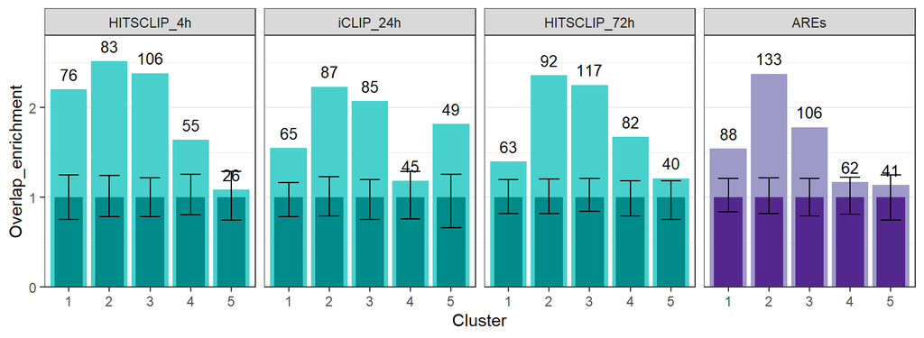

```r
ARE_total_overlaps <- sapply(ls(pattern = "TATT_cluster"), function(x) get(x)$median[1])

summary_clusters_24hCLIP %>%
  add_column(Dataset = "iCLIP_24h") %>%
  bind_rows(add_column(summary_clusters_4hCLIP, Dataset = "HITSCLIP_4h")) %>%
  bind_rows(add_column(summary_clusters_72hCLIP, Dataset = "HITSCLIP_72h")) %>%
  add_column(Type = "CLIP") %>%
  bind_rows({
    TATTTATT_summary_norm %>%
      add_column(Dataset = "AREs") %>%
      add_column(Type = "ARE") %>%
      rename(Overlap_enrichment = median_cluster) %>%
      rename(q5_enrichment = q5_Expression_matched) %>%
      rename(q95_enrichment = q95_Expression_matched) %>%
      add_column(Total_overlaps = ARE_total_overlaps)
      }) %>%
  mutate(Dataset = factor(Dataset, levels = c("HITSCLIP_4h", "iCLIP_24h", "HITSCLIP_72h", "AREs"))) %>%
  mutate(Type2 = paste0(Type, "2")) %>%
  ggplot(aes(x = Cluster, y = Overlap_enrichment)) +
    geom_col(aes(fill = Type)) +
    geom_col(aes(y = 1, fill = Type2), width=0.7) +
    geom_errorbar(aes(ymin = q5_enrichment, ymax = q95_enrichment), width=0.5) +
    geom_text(aes(label = Total_overlaps), vjust = 0, nudge_y = 0.1, size = 3.5) +
    facet_grid(~Dataset) +
    theme_bw() +
    theme(panel.grid.major.x = element_blank(), legend.position = "none", plot.background = element_blank(), panel.background = element_blank()) +
    scale_fill_manual(breaks = c("CLIP", "CLIP2", "ARE", "ARE2"), values = c("mediumturquoise", "darkcyan", brewer.pal(6,"Purples")[4], brewer.pal(6,"Purples")[6])) +
    coord_cartesian(ylim = c(0,2.8)) +
    scale_y_continuous(expand = c(0,0))
```

```r
ggsave("Figure_panels/Fig2CD_CLIPAREenrich.pdf")
```

# Figure 2E-F: gene set analyses

## Gene set and background control lists

For GO term analysis, we want to consider all genes together (ie everything used for the clustering). For TRANSFAC, only those with increased transcription (clusters 3-5). We will use gene IDs since these are more stable.

For the background list, select genes with base mean > 25 in standard mRNA-seq, and convert gene names to IDs based on GTF.

```r
up_all_L2FC %>%
  mutate(Gene_ID = GRCm38_90_gtf$gene_id[match(Gene, GRCm38_90_gtf$gene_name)]) %>%
  pull(Gene_ID) %>%
  write("GO_term_analysis/all_clusters.txt")

up_all_L2FC %>%
  filter(clustersCor %in% c("3", "4", "5")) %>%
  mutate(Gene_ID = GRCm38_90_gtf$gene_id[match(Gene, GRCm38_90_gtf$gene_name)]) %>%
  pull(Gene_ID) %>%
  write("GO_term_analysis/cluster345.txt")
res_RNA %>%
  filter(baseMean > 25) %>%
  mutate(Gene_ID = GRCm38_90_gtf$gene_id[match(Gene, GRCm38_90_gtf$gene_name)]) %>%
  pull(Gene_ID) %>%
  write("GO_term_analysis/Background_expressed.txt")
```

## GO biological process

GO term analysis against Biological Process terms was performed using GOrilla, with the background list above, for the genes comprising all five clusters. Results exported and saved into a text file.

### Filtering and REVIGO analysis

Results include a lot of redundancy - I will filter these to include only terms with enrichment > 2, and then run through REVIGO to reduce redundancy (using enrichment as the metric to decide representative terms, since this gives the more specific terms).

```r
read_tsv("GO_term_analysis/GOrilla_all_clusters.txt") %>%
  rename_with(~ gsub("[ -]", "_", .x)) %>%
  filter(FDR_q_value < 0.05 & Enrichment > 2) -> GOrilla_cluster1
GOrilla_cluster1 %>%
  select(GO_Term, Enrichment) %>%
  write_tsv("GO_term_analysis/all_clusters_sig_enrich2.txt")
```

Reduced these using REVIGO (http://revigo.irb.hr/), based on semantic similarity, allowing small similarity and prioritising terms with higher enrichment as representative terms.

For the reduced list, will plot the top 20 based on adjusted p value (add these back in from the original GO term analysis).

Complete results (filtered for enrichment > 2 and FDR < 0.05, but including terms removed by REVIGO) will be included as supplementary tables.

```r
read_tsv("GO_term_analysis/Revigo_all_clusters.tsv") %>%
  left_join(GOrilla_cluster1, by = c("TermID" = "GO_Term")) -> Revigo_all_clusters
```

### Table S8 - gene set enrichment

First write out table for supplementary (before re-ordering/filtering)

This will be combined with TRANSFAC output into a single table in Excel

```r
Revigo_all_clusters %>%
  select(1,15,6,7,13,14,16:23) %>%
    write_tsv("Supplementary_tables/TableS8_GOallclusters.txt")
```

### Plot data

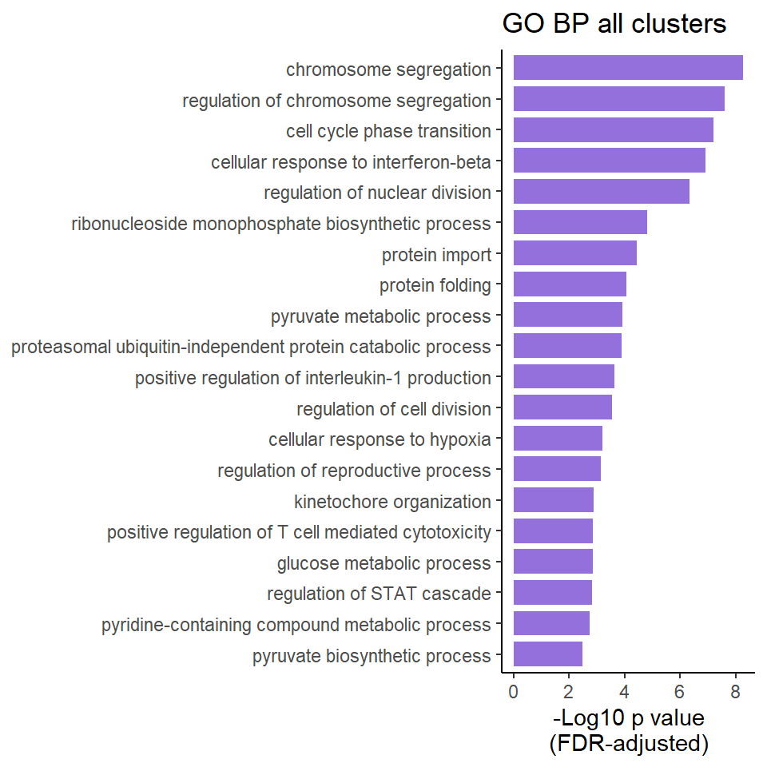

```r
Revigo_all_clusters %>%
  filter(Eliminated == FALSE) %>%
  arrange(FDR_q_value) %>%
  mutate(Description = factor(Description, levels = rev(Description))) %>%
  slice(1:20) %>%
  ggplot(aes(x = Description, y = -log10(FDR_q_value))) +
    geom_col(fill = "mediumpurple", width = 0.8) +
    coord_flip() +
    labs(x = NULL, y = "-Log10 p value\n(FDR-adjusted)", title = "GO BP all clusters")
```

```r
ggsave("Figure_panels/Fig2E_GOBP.pdf")
```

## TRANSFAC - enrichment for TF binding sites

Ran genes comprising clusters 3-5 (all show increased transcription) together through gProfiler, with the same background list as above, with just the TRANSFAC data source.

### Plot data

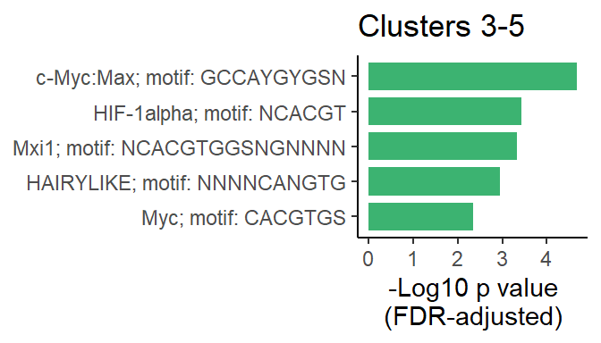

```r
read_tsv("GO_term_analysis/cluster3_4_5_gProfiler_TRANSFAC.txt") %>%
  mutate(term_name = sub("Factor: (.*motif.*?);.*", "\\1", term_name)) %>%
  mutate(term_name = factor(term_name, levels= rev(term_name))) %>%
  ggplot(aes(x = term_name, y = negative_log10_of_adjusted_p_value)) +
    geom_col(fill = "mediumseagreen", width = 0.8) +
    coord_flip() +
    labs(y = "-Log10 p value\n(FDR-adjusted)", x = NULL, title= "Clusters 3-5")
```

```r
ggsave("Figure_panels/Fig2F_TRANSFAC_cluster345.pdf")
```

# Table S6 - clusters

Want to include TATTTATT motifs in 3’UTR, and CLIP targets.

For TATTTATT, I only created a summary, so first need to read the output from the TATT analysis for each of the clusters. Genes that aren’t present in these outputs are those without a 3’UTR - so can set NAs to 0 once I’ve merged the tables, since by definition they can’t have any TATTTATTs in a 3’UTR if they don’t have one!

```r
read_tsv("Clusters/TATT_cluster1_CLIP_72h_exMatch_expression_matched.txt") %>%
  filter(Gene_set == "cluster1") %>%
  select(Gene, nTATTTATT, transcript_id) %>%
  bind_rows({
    read_tsv("Clusters/TATT_cluster2_CLIP_72h_exMatch_expression_matched.txt") %>%
      filter(Gene_set == "cluster2") %>%
      select(Gene, nTATTTATT, transcript_id)
  }) %>%
  bind_rows({
    read_tsv("Clusters/TATT_cluster3_CLIP_72h_exMatch_expression_matched.txt") %>%
      filter(Gene_set == "cluster3") %>%
      select(Gene, nTATTTATT, transcript_id)
  }) %>%
  bind_rows({
    read_tsv("Clusters/TATT_cluster4_CLIP_72h_exMatch_expression_matched.txt") %>%
      filter(Gene_set == "cluster4") %>%
      select(Gene, nTATTTATT, transcript_id)
  }) %>%
  bind_rows({
    read_tsv("Clusters/TATT_cluster5_CLIP_72h_exMatch_expression_matched.txt") %>%
      filter(Gene_set == "cluster5") %>%
      select(Gene, nTATTTATT, transcript_id)
  }) %>%
  rename(Gene_ID = Gene) -> nTATTTATT_all_clusters
up_all_L2FC %>%
  mutate(Gene_ID = GRCm38_90_gtf$gene_id[match(Gene, GRCm38_90_gtf$gene_name)]) %>%
  select(Gene, Gene_ID, Nascent_zscore, Stability_zscore, RNA_zscore, Ribo_zscore, clustersCor) %>%
  mutate(CLIP_4h = Gene_ID %in% Darnell_4h_3UTR_targets) %>%
  mutate(iCLIP_24h = Gene_ID %in% iCLIP_24h_3UTR_targets) %>%
  mutate(CLIP_72h = Gene_ID %in% Darnell_72h_3UTR_targets) %>%
  left_join(nTATTTATT_all_clusters) %>%
  mutate(row_id = row_number()) %>%
  arrange(match(row_id, up_all_hcCor$order)) %>%
  select(-row_id) %>%
  write_tsv("Supplementary_tables/TableS6_clusters.txt")
```

# CLIP binding profiles

Need to write a function to plot the CLIP binding profile for a given gene, in a given CLIP dataset. I will write this to take transcript names - so would first need to use eg Ensembl to decide which isoform we want to plot. My preference is to plot all crosslink sites irrespective of the FDR, so signal to noise ratio is clear - so also need to read these in and save.

```r
read_tsv("CLIP_data/BRF1_2_Tis11b_all_merged_grouped_scores_annotated.tsv.gz") %>%
  distinct(chromosome, start, strand, .keep_all = T) -> iCLIP_24h_all_xl_sites
read_tsv("CLIP_data/WT_4h_merged_grouped_scores_annotated.tsv.gz") %>%
  distinct(chromosome, start, strand, .keep_all = T) -> CLIP_4h_all_xl_sites
read_tsv("CLIP_data/WT_3d_merged_grouped_scores_annotated.tsv.gz") %>%
  distinct(chromosome, start, strand, .keep_all = T) -> CLIP_72h_all_xl_sites
```

For conservation tracks, we will use phyloP scores from a 60-way multiple alignment, averaged over a 7 base sliding window.

60-way phyloP scores for each chromosome were downloaded from UCSC and converted to BED format with bash script (download_mm10_phyloP60_chr_wig2bed.sh).

Then filtered to include only regions surrounding genes of interest using pull_out_phyloP.R script.

Read in filtered phyloP scores:

```r
read_tsv("seq_conservation/PhyloP_selected_regions_CD4manuscript.txt") %>%
  rename(chromosome = seqnames) -> phyloP_selected
```

smooth by calculating average in 7 base windows

```r
phyloP_selected %>%
  group_by(chromosome) %>%
  mutate(score_smooth = slider::slide_mean(score, before = 3, after =3)) -> phyloP_selected
```

For function, optionally can provide zoom_min and/or zoom_max if you want to display only a portion of the gene (eg only the 3’ end). Can also set displayTATT to TRUE if you want to show locations of TATT motifs (if >1 transcript isoform listed, will only plot these on the first)

```r
plot_CLIP_profile = function(Transcript, CLIPdata = CLIP_72h_all_xl_sites, zoom_min = NA, zoom_max = NA, displayTATT = F, consPlot = F, consData = phyloP_selected, max_cons = max(abs(consData$score_smooth))) {
  GRCm38_90_gtf[GRCm38_90_gtf$transcript_name %in% Transcript & GRCm38_90_gtf$type %in% c("CDS", "stop_codon", "five_prime_utr", "three_prime_utr")] %>%
    as_tibble() %>%
    select(seqnames, start, end, strand, type, transcript_name) %>%
    mutate(type = if_else(type %in% c("CDS", "stop_codon"), "CDS", "UTR")) %>%
    mutate(exon_start = if_else(strand == "+", start - 0.5, end + 0.5)) %>%
    mutate(exon_end = if_else(strand == "+", end + 0.5, start - 0.5)) %>%
    group_by(transcript_name) %>%
    mutate(transcript_offset = which(unique(transcript_name) == Transcript)) %>%
    ungroup() -> transcript_coord
  if(transcript_coord$strand[1] == "+") {
    transcript_coord %>%
      arrange(transcript_offset, exon_start) -> transcript_coord
  } else {
    transcript_coord %>%
      arrange(transcript_offset, desc(exon_start)) -> transcript_coord
  }
  transcript_coord %>%
    group_by(transcript_offset) %>%
    mutate(intron_start = exon_end, intron_end = lead(exon_start)) %>%
    mutate(intron_start = if_else(intron_start == intron_end, NA_real_, intron_start)) %>%
    mutate(intron_end = if_else(is.na(intron_start), NA_real_, intron_end)) %>%
    ungroup() -> transcript_coord

  if(is.na(zoom_min)) {
    zoom_min <- min(transcript_coord$start)
  }
  if(is.na(zoom_max)) {
    zoom_max <- max(transcript_coord$end)
  }

  CLIPdata %>%
    filter(chromosome == paste0("chr", transcript_coord$seqnames[1])) %>% # NB this won't work for MT but I don't need it to for my purposes.
    filter(start >= zoom_min & start <= zoom_max) %>%
    mutate(score_norm = score/max(score)) -> CLIPdata

  ggplot() +
    geom_rect(data = CLIPdata, aes(xmin = start-0.5, xmax = start+0.5, ymin = 0, ymax = score_norm), fill = "royalblue4", colour = "royalblue4") +
    geom_rect(data = transcript_coord, aes(xmin = exon_start, xmax = exon_end, fill = type, ymin = (-transcript_offset/2)+0.1, ymax = (-transcript_offset/2)+0.4), colour = "royalblue4") +
    scale_fill_manual(name = NULL, values = c("royalblue4","transparent")) +
    geom_segment(data = transcript_coord, aes(x = intron_start, xend = intron_end, y = (-transcript_offset/2)+0.15, yend = (-transcript_offset/2)+0.25), colour  = "royalblue4") +
    geom_segment(data = transcript_coord, aes(x = intron_start, xend = intron_end, y = (-transcript_offset/2)+0.35, yend = (-transcript_offset/2)+0.25), colour  = "royalblue4") +
    annotate("text",x = zoom_min, y = 1, label = max(CLIPdata$score), vjust = 0.5, hjust = 0)+
    geom_hline(yintercept = 0) +
    theme(axis.line = element_blank()) +
    coord_cartesian(xlim = c(zoom_min-1, zoom_max+1)) +
    scale_x_continuous(expand = c(0,0)) +
    labs(x = paste("Chromosome", transcript_coord$seqnames[1]), y = "CLIP crosslinks", title = paste(Transcript, collapse = "; ")) -> CLIPplot

  if(displayTATT == T) {
    getSeq(BSgenome.Mmusculus.UCSC.mm10, paste0("chr", transcript_coord$seqnames[1]), zoom_min, zoom_max, strand = transcript_coord$strand[1], as.character = T) -> transcript_seq
    TATT_indices <- gregexpr("(?=TATT)", transcript_seq, perl=T)[[1]]
    if(transcript_coord$strand[1] == "+") {
      TATT_indices <- TATT_indices + zoom_min - 1
    } else {
      TATT_indices <- zoom_max - (TATT_indices+2)
    }
    CLIPplot +
    geom_rect(aes(xmin = TATT_indices-0.5, xmax = TATT_indices+3.5, ymin = -0.4, ymax = -0.1), colour = "orange", fill = "orange") -> CLIPplot
  }

  if(consPlot == T){
    consData %>%
      filter(chromosome == paste0("chr", transcript_coord$seqnames[1])) %>% # NB this won't work for MT but I don't need it to for my purposes.
      filter(start >= zoom_min & start <= zoom_max) %>%
      mutate(score_smooth = (score_smooth/(2*max_cons))-(max(transcript_coord$transcript_offset)/2+0.5)) -> consData
    CLIPplot +
      geom_hline(yintercept = -(max(transcript_coord$transcript_offset)/2+0.5)) +
      geom_line(data = consData, aes(x = start, y = score_smooth)) -> CLIPplot
  }

  return(CLIPplot)
}
```

Will generate plots now for all the genes I want to show.

May not want both complete gene and zoomed in on 3’UTR for all of them, but will create them in case.

## Figure S2

### Hk2

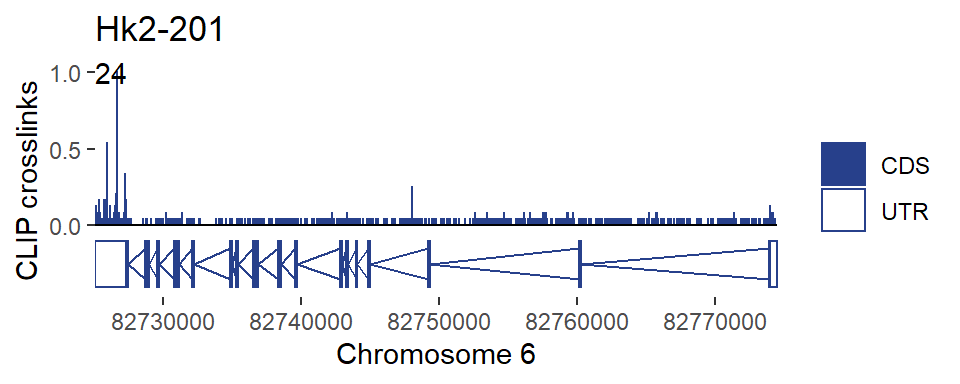

```r
plot_CLIP_profile("Hk2-201")
```

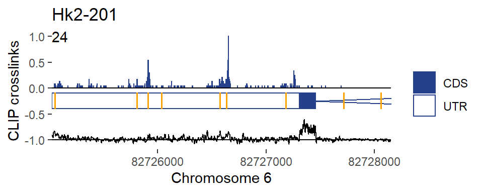

```r
ggsave("Figure_panels/FigS2A_Hk2CLIP_complete.pdf")
plot_CLIP_profile("Hk2-201", zoom_max = 82728150, displayTATT = T, consPlot = T)
```

```r
ggsave("Figure_panels/FigS2A_Hk2CLIP_3UTR.pdf")
```

### Pfkfb3

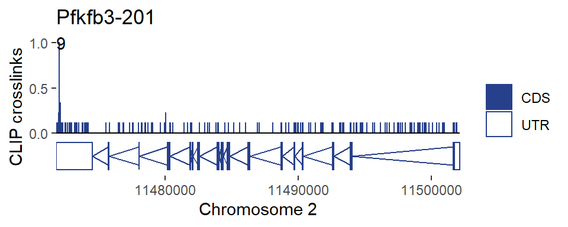

```r
plot_CLIP_profile("Pfkfb3-201")
```

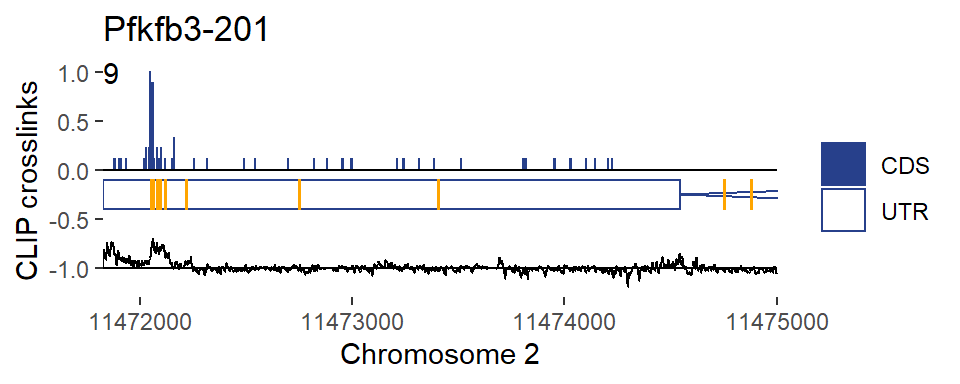

```r
ggsave("Figure_panels/FigS2A_Pfkfb3CLIP_complete.pdf")
plot_CLIP_profile("Pfkfb3-201", zoom_max = 11475000, displayTATT = T, consPlot = T)
```

```r
ggsave("Figure_panels/FigS2A_Pfkfb3CLIP_3UTR.pdf")
```

### Myc

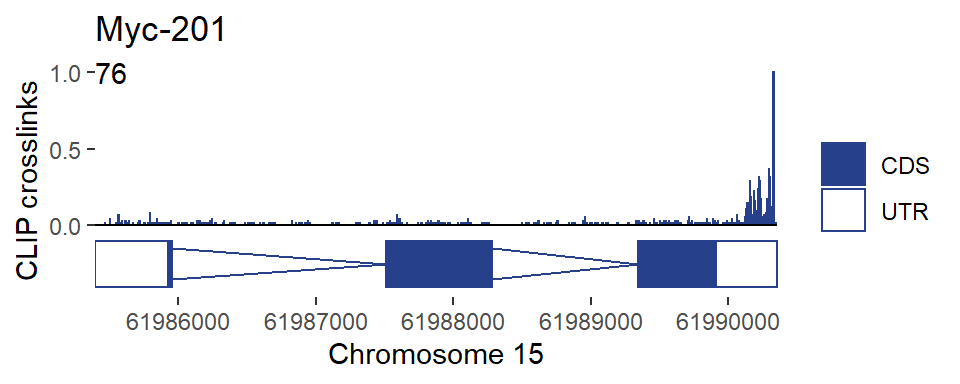

```r
plot_CLIP_profile("Myc-201")
```

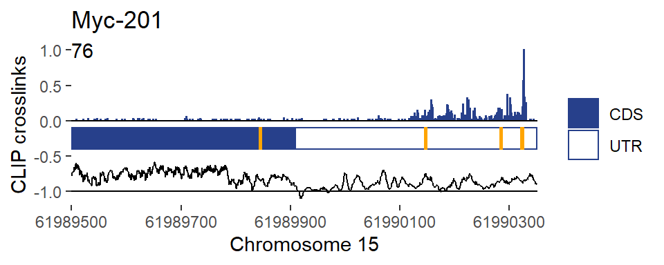

```r
ggsave("Figure_panels/FigS2A_MycCLIP_complete.pdf")
plot_CLIP_profile("Myc-201", zoom_min = 61989500, displayTATT = T, consPlot = T)
```

```r
ggsave("Figure_panels/FigS2A_MycCLIP_3UTR.pdf")
```

### Hif1a

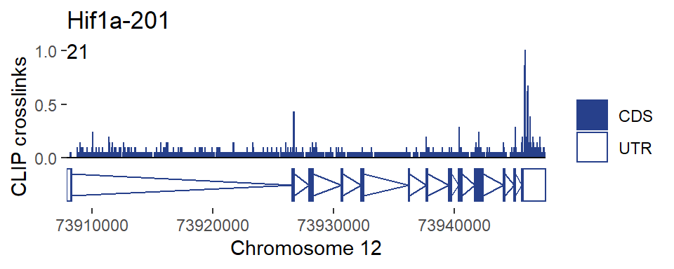

```r
plot_CLIP_profile("Hif1a-201")
```

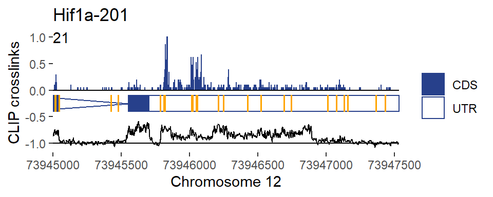

```r
ggsave("Figure_panels/FigS2A_Hif1aCLIP_complete.pdf")
plot_CLIP_profile("Hif1a-201", zoom_min = 73945000, displayTATT = T, consPlot = T)
```

```r
ggsave("Figure_panels/FigS2A_Hif1aCLIP_3UTR.pdf")
```

### Slc2a1

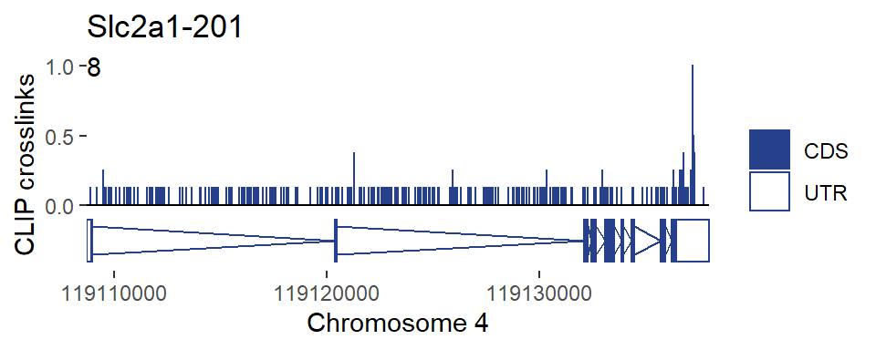

```r
plot_CLIP_profile("Slc2a1-201")
```

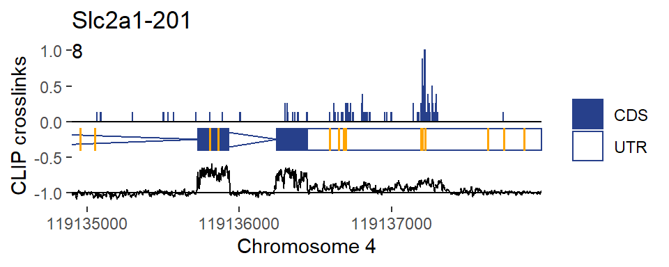

```r
ggsave("Figure_panels/FigS2B_Slc2a1CLIP_complete.pdf")
plot_CLIP_profile("Slc2a1-201", zoom_min = 119134900, displayTATT = T, consPlot = T)
```

```r
ggsave("Figure_panels/FigS2B_Slc2a1CLIP_3UTR.pdf")
```

### Slc2a3

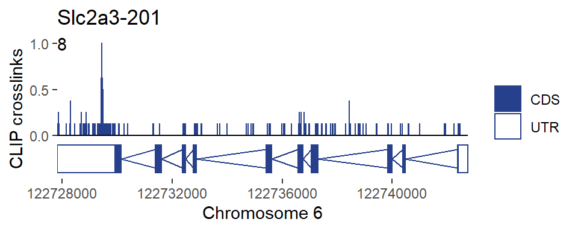

```r
plot_CLIP_profile("Slc2a3-201")
```

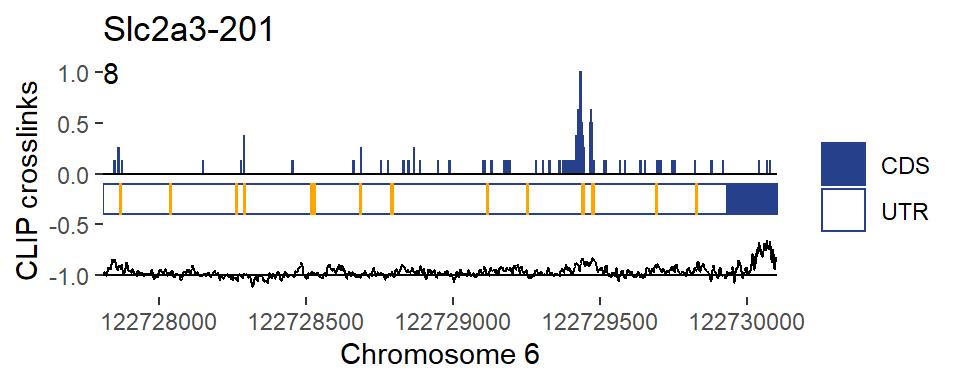

```r
ggsave("Figure_panels/FigS2C_Slc2a3CLIP_complete.pdf")
plot_CLIP_profile("Slc2a3-201", zoom_max = 122730100, displayTATT = T, consPlot = T)
```

```r
ggsave("Figure_panels/FigS2C_Slc2a3CLIP_3UTR.pdf")
```

### Pfkp

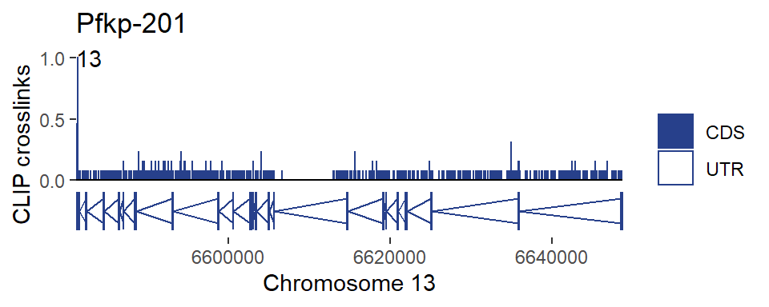

```r
plot_CLIP_profile("Pfkp-201")
```

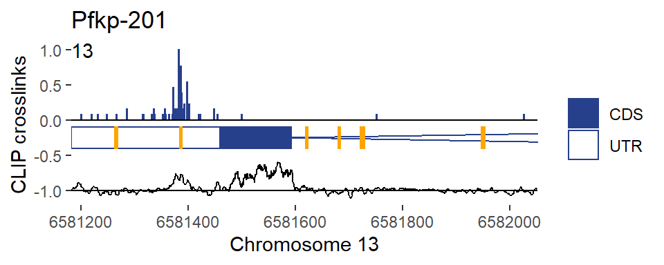

```r
ggsave("Figure_panels/FigS2F_PfkpCLIP_complete.pdf")
plot_CLIP_profile("Pfkp-201", zoom_max = 6582050, displayTATT = T, consPlot = T)
```

```r
ggsave("Figure_panels/FigS2F_PfkpCLIP_3UTR.pdf")
```